### Group 27 Shakil Ahmed - 202402609 Al Ashrif Bin Ahamed - 202402610

# Data Mining - Handin 1 - Clustering

Welcome to the handin on clustering algorithms and outlier detection. This handin corresponds to the topics in Week 5--9 in the course.

The handin is

- done in the chosen handin groups
- worth 10% of the final grade

For the handin, you will prepare a report in PDF format, by exporting the Jupyter notebook. Please submit

1. The jupyter notebook file with your answers
2. The PDF obtained by exporting the jupyter notebook

**The grading system**: Tasks are assigned a number of points based on the difficulty and time to solve it. The sum of the number of points is 100. For the maximum grade you need to get at least *90 points*. The minimum grade (02 in the Danish scale) requires **at least** 30 points, with at least 8 points from the first three Parts (Part 1,2,3) and 6 points in the last part (Part 4).

**The exercise types**: There are four different types of exercises

1. **[Compute by hand]** means that you should provide NO code, but show the main steps to reach the result (not all).
2. **[Motivate]** means to provide a short answer of 1-5 lines indicating the main reasoning, e.g., the PageRank of a complete graph is 1/n in all nodes as all nodes are symmetric and are connected one another.
3. **[Prove]** means to provide a formal argument and NO code.
4. **[Implement]** means to provide an implementation. Unless otherwise specified, you are allowed to use helper functions (e.g., `np.mean`, `itertools.combinations`, and so on). **However**, if the task is to implement an algorithm, by no means a call to a library that implements the same algorithm will be deemed as sufficient!

**Q&A**

Q: If the task is to implement a mean function, may I just call `np.mean()`?  
A: No.

Q: If the task is to compare the mean of X and Y, may I use `np.mean()` to calculate the mean?  
A: Yes.

Q: If I have implemented a mean function in a previous task, but I am unsure of its correctness, may I use `np.mean()` in following task where mean is used as a helper function?  
A: Yes.

Q: May I use `np.mean()` to debug my implementation of mean?  
A: Yes.

Q: Do I get 0 points for a task if I skip it?  
A: Yes.

Q: Can I get partial points for a task I did partially correct?  
A: Yes.

Q: Is it OK to skip a task if I do not need the points from it?  
A: Yes.

Q: Should I inform a TA if I find an error?  
A: Yes.

Q: Should I ask questions if I am confused?  
A: Yes.

Good luck!

```python
## DO NOT TOUCH
import numpy as np
import pandas as pd
import warnings
from sklearn.cluster import KMeans, DBSCAN
from sklearn.datasets import load_wine
from sklearn.preprocessing import StandardScaler
import time
import seaborn as sns


RANDOM_SEED = 132414
## DO NOT TOUCH
warnings.filterwarnings('ignore')
%matplotlib inline
import matplotlib.pyplot as plt

wine = load_wine()
df = pd.DataFrame(data=wine.data, columns=wine.feature_names)
df['target'] = wine.target
color_map = {0:'Blue', 1:'Red', 2:'Green'}
toy = df.sample(n=15, random_state=RANDOM_SEED)
toy
```

|  | alcohol | malic_acid | ash | alcalinity_of_ash | magnesium | total_phenols | flavanoids | nonflavanoid_phenols | proanthocyanins | color_intensity | hue | od280/od315_of_diluted_wines | proline | target |
| --- | --- | --- | --- | --- | --- | --- | --- | --- | --- | --- | --- | --- | --- | --- |
| 117 | 12.42 | 1.61 | 2.19 | 22.5 | 108.0 | 2.00 | 2.09 | 0.34 | 1.61 | 2.06 | 1.06 | 2.96 | 345.0 | 1 |
| 6 | 14.39 | 1.87 | 2.45 | 14.6 | 96.0 | 2.50 | 2.52 | 0.30 | 1.98 | 5.25 | 1.02 | 3.58 | 1290.0 | 0 |
| 18 | 14.19 | 1.59 | 2.48 | 16.5 | 108.0 | 3.30 | 3.93 | 0.32 | 1.86 | 8.70 | 1.23 | 2.82 | 1680.0 | 0 |
| 91 | 12.00 | 1.51 | 2.42 | 22.0 | 86.0 | 1.45 | 1.25 | 0.50 | 1.63 | 3.60 | 1.05 | 2.65 | 450.0 | 1 |
| 110 | 11.46 | 3.74 | 1.82 | 19.5 | 107.0 | 3.18 | 2.58 | 0.24 | 3.58 | 2.90 | 0.75 | 2.81 | 562.0 | 1 |
| 129 | 12.04 | 4.30 | 2.38 | 22.0 | 80.0 | 2.10 | 1.75 | 0.42 | 1.35 | 2.60 | 0.79 | 2.57 | 580.0 | 1 |
| 39 | 14.22 | 3.99 | 2.51 | 13.2 | 128.0 | 3.00 | 3.04 | 0.20 | 2.08 | 5.10 | 0.89 | 3.53 | 760.0 | 0 |
| 114 | 12.08 | 1.39 | 2.50 | 22.5 | 84.0 | 2.56 | 2.29 | 0.43 | 1.04 | 2.90 | 0.93 | 3.19 | 385.0 | 1 |
| 1 | 13.20 | 1.78 | 2.14 | 11.2 | 100.0 | 2.65 | 2.76 | 0.26 | 1.28 | 4.38 | 1.05 | 3.40 | 1050.0 | 0 |
| 116 | 11.82 | 1.47 | 1.99 | 20.8 | 86.0 | 1.98 | 1.60 | 0.30 | 1.53 | 1.95 | 0.95 | 3.33 | 495.0 | 1 |
| 29 | 14.02 | 1.68 | 2.21 | 16.0 | 96.0 | 2.65 | 2.33 | 0.26 | 1.98 | 4.70 | 1.04 | 3.59 | 1035.0 | 0 |
| 119 | 12.00 | 3.43 | 2.00 | 19.0 | 87.0 | 2.00 | 1.64 | 0.37 | 1.87 | 1.28 | 0.93 | 3.05 | 564.0 | 1 |
| 125 | 12.07 | 2.16 | 2.17 | 21.0 | 85.0 | 2.60 | 2.65 | 0.37 | 1.35 | 2.76 | 0.86 | 3.28 | 378.0 | 1 |
| 154 | 12.58 | 1.29 | 2.10 | 20.0 | 103.0 | 1.48 | 0.58 | 0.53 | 1.40 | 7.60 | 0.58 | 1.55 | 640.0 | 2 |
| 118 | 12.77 | 3.43 | 1.98 | 16.0 | 80.0 | 1.63 | 1.25 | 0.43 | 0.83 | 3.40 | 0.70 | 2.12 | 372.0 | 1 |

# Part 1 Intro Excercises

## Task 1.1 K-Means and DBScan

### Task 1.1.1 (4 points)

**[Compute by hand]** the cluster assignments *for the dataset below* using k-means and $k = 2$, with initial centroids being (2.2, 0.9) and (2.3, 1.0)

To evaluate (i.e., only to control the correctness and not to solve the exercise) your results you can use **sklearn.cluster.KMeans**.

```
      ash   hue
117  2.19  1.06
6    2.45  1.02
18   2.48  1.23
91   2.42  1.05
110  1.82  0.75
129  2.38  0.79
39   2.51  0.89
114  2.50  0.93
1    2.14  1.05
116  1.99  0.95
29   2.21  1.04
119  2.00  0.93
125  2.17  0.86
154  2.10  0.58
118  1.98  0.70
```

```
(np.float64(1.7855),
 np.float64(2.5444999999999998),
 np.float64(0.5475),
 np.float64(1.2625))
```

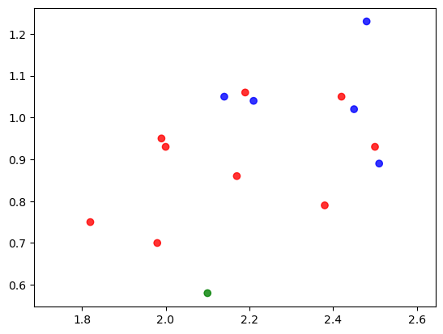

```python
first = 'ash'
last = 'hue'

X_kmeans = toy[[first, last]]
print(X_kmeans)

plt.scatter(X_kmeans[first], X_kmeans[last], alpha=0.8, c=toy['target'].map(color_map))
plt.axis('equal')
```

**YOUR ANSWER HERE**

[figure not shown]

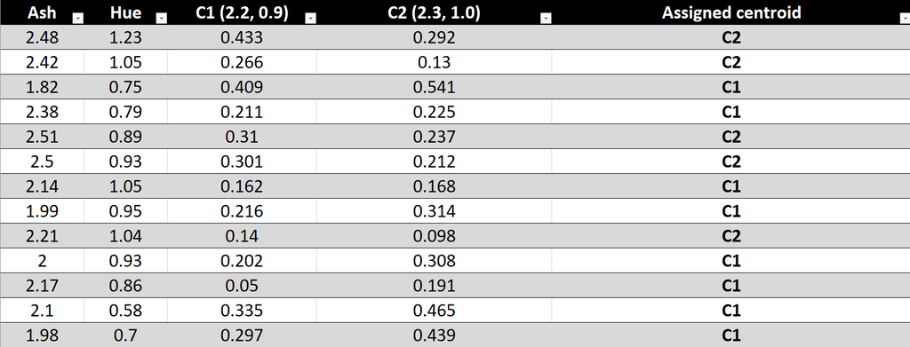

So, the clusters are -> `Cluster 1` = $[(1.82, 0.75), (2.38, 0.79), (2.14, 1.05), (1.99, 0.95), (2, 0.93), (2.17, 0.86), (2.1, 0.58), (1.98, 0.7)]$

`Cluster 2` = $[(2.19, 1.06), (2.45, 1.02), (2.48, 1.23), (2.42, 1.05), (2.51, 0.89), (2.5, 0.93), (2.21, 1.04)]$

count of `Cluster 1` = 8

count of `Cluster 2` = 7

**For updating the centroid -->**

for `C1` = $(1.82 + 2.38 + 2.14 + 1.99 + 2 + 2.17 + 2.1 + 1.98) / 8, (0.75 + 0.79 + 1.05 + 0.95 + 0.93 + 0.86 + 0.58 + 0.7) /8 $

New `C1` = $(2.07, 0.83)$

for `C2` = $(2.19 + 2.45 + 2.48 + 2.42 + 2.51 + 2.5 + 2.21) / 7, (1.06 + 1.02 + 1.23 + 1.05 + 0.89 + 0.93 + 1.04) / 7 $

New `C2` = $(2.39, 1.03)$

Again, with the new centroid we need to calculate the distance

Euclidean Distance = $ \sqrt{(x1-x2)^2 + (y1-y2)^2}$

ash, hue (2.19, 1.06) = $ \sqrt{(2.07-2.19)^2 + (0.83-1.06)^2}$ = $0.259$ = `C1`

ash, hue (2.19, 1.06) = $ \sqrt{(2.39-2.19)^2 + (1.03-1.06)^2}$ = $0.202$ = `C2`

Therefore, `C1` > `C2`, then assigned it in `C2`

for rest of the data, please see the table below:

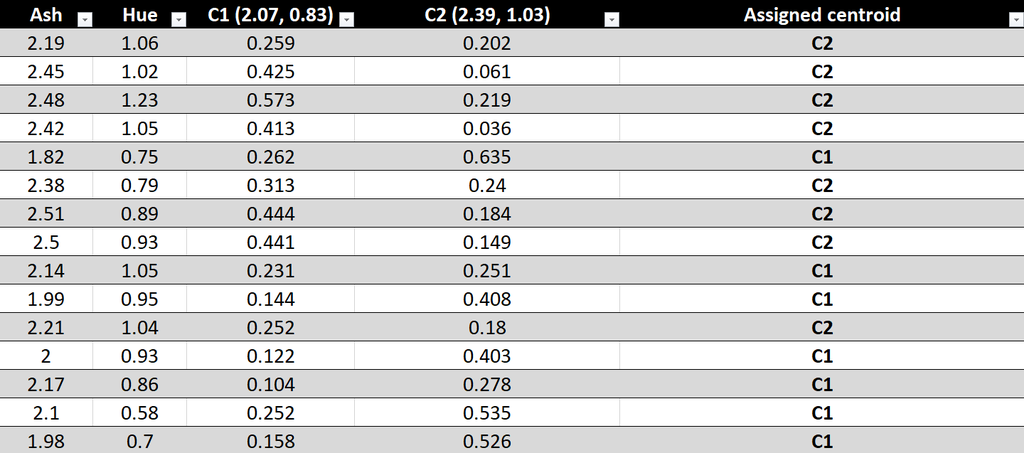

So, the final clusters are -> `Cluster 1` = $[(1.82, 0.75), (2.14, 1.05), (1.99, 0.95), (2, 0.93), (2.17, 0.86), (2.1, 0.58), (1.98, 0.7)]$

`Cluster 2` = $[(2.19, 1.06), (2.45, 1.02), (2.48, 1.23), (2.42, 1.05), (2.38, 0.79), (2.51, 0.89), (2.5, 0.93), (2.21, 1.04)]$

And **New Centroid**

`C1` = $(2.02, 0.83)$

`C2` = $(2.39, 1.00)$

```python
X_kmeans.values.tolist()
```

```
[[2.19, 1.06],
 [2.45, 1.02],
 [2.48, 1.23],
 [2.42, 1.05],
 [1.82, 0.75],
 [2.38, 0.79],
 [2.51, 0.89],
 [2.5, 0.93],
 [2.14, 1.05],
 [1.99, 0.95],
 [2.21, 1.04],
 [2.0, 0.93],
 [2.17, 0.86],
 [2.1, 0.58],
 [1.98, 0.7]]
```

### Task 1.1.2 (3 points)

**[Compute by hand]**  
A) Using examples, show why the k-means algorithm may not find the global optimum.

**YOUR ANSWER HERE**

**Let take these 5 points:** $A(1,1), B(2,1), C(4,3), D(5,4), E(8,8)$ and suppose, $k = 2$

Initialize Cluster Centers (Randomly Chosen) Let’s assume we randomly select $A(1,1)$ and $E(8,8)$ as the initial centroids.

Then Assign Each Point to the Nearest Cluster We calculate the distance of each point to the centroids:

- Distance from A(1,1) to:
- A(1,1) = 0 (belongs to Cluster 1)
- B(2,1) = 1 (belongs to Cluster 1)
- C(4,3) = 3.61 (belongs to Cluster 1)
- D(5,4) = 5 (belongs to Cluster 1)
- E(8,8) = 9.89 (belongs to Cluster 2)

Distance from E(8,8) to:

- A(1,1) = 9.89 (belongs to Cluster 1)
- B(2,1) = 9 (belongs to Cluster 1)
- C(4,3) = 5.66 (belongs to Cluster 1)
- D(5,4) = 5 (belongs to Cluster 1)
- E(8,8) = 0 (belongs to Cluster 2) After assigning points:
- Cluster 1: A(1,1), B(2,1), C(4,3), D(5,4)
- Cluster 2: E(8,8)

Now, Compute New Centroids

- New centroid for Cluster 1: Mean of (1,1), (2,1), (4,3), (5,4)

${(1+2+4+5)/4, (1+1+3+4)/4} = (3,2.25)$

- New centroid for Cluster 2 remains (8,8).

**However, If we had chosen C(4,3) and E(8,8) as the initial centroids instead, the clustering could have been different and possibly better in terms of minimizing the total distance. K-Means relies on random initialization, so it can sometimes settle in a local minimum instead of the global clustering.**

**Observations**

- Sum-of-squares minimization is non-convex, meaning multiple local minima exist.
- Poorly (randomly) chosen centroid.
- If updates are locally optimal, no guarantee of global optimal.

**[Motivate]**  
B) K-means vs K-medoids: Which performs better when the dataset contains outliers, and why?

**YOUR ANSWER HERE**

**K-medoids is better than K-means in terms of managing outliers. The main reason is k-medoids selects actual datapoints from clusters which is not more into extreme values. On the other hand K-means uses mean value which is sensitive to the outliers.**

**For example ->**

suppose, $[2, 3, 4, 5, 40]$ are the group of numbers.

**For K-means** = $2+3+4+5+40/5 = 54/5 = 10.8$ is a center which is far away from the actual centroid. So that, it makes the cluster center inaccurate.

**For K-medoids** = It picks one of the actual value as the center (e,g. 4) by negating the extreme value.

### Task 1.1.3 (4 points)

**[Compute by hand]** the dendrogram for the dataset of Task 1.1.1. using **complete-link**.

**YOUR ANSWER HERE**

|  | A | B | C | D | E | F | G | H | I | J | K | L | M | N | O |
| --- | --- | --- | --- | --- | --- | --- | --- | --- | --- | --- | --- | --- | --- | --- | --- |
| A | 0 | 0.26 | 0.34 | 0.23 | 0.48 | 0.33 | 0.36 | 0.34 | 0.05 | 0.23 | 0.03 | 0.23 | 0.20 | 0.49 | 0.42 |
| B | 0.26 | 0 | 0.21 | 0.04 | 0.69 | 0.24 | 0.14 | 0.10 | 0.31 | 0.47 | 0.24 | 0.46 | 0.32 | 0.56 | 0.57 |
| C | 0.34 | 0.21 | 0 | 0.19 | 0.82 | 0.45 | 0.34 | 0.30 | 0.38 | 0.56 | 0.33 | 0.57 | 0.48 | 0.75 | 0.73 |
| D | 0.23 | 0.04 | 0.19 | 0 | 0.67 | 0.26 | 0.18 | 0.14 | 0.28 | 0.44 | 0.21 | 0.44 | 0.31 | 0.57 | 0.56 |
| E | 0.48 | 0.69 | 0.82 | 0.67 | 0 | 0.56 | 0.70 | 0.70 | 0.44 | 0.26 | 0.49 | 0.25 | 0.37 | 0.33 | 0.17 |
| F | 0.33 | 0.24 | 0.45 | 0.26 | 0.56 | 0 | 0.16 | 0.18 | 0.35 | 0.42 | 0.30 | 0.40 | 0.22 | 0.35 | 0.41 |
| G | 0.36 | 0.14 | 0.34 | 0.18 | 0.70 | 0.16 | 0 | 0.04 | 0.40 | 0.52 | 0.34 | 0.51 | 0.34 | 0.51 | 0.56 |
| H | 0.34 | 0.10 | 0.30 | 0.14 | 0.70 | 0.18 | 0.04 | 0 | 0.38 | 0.51 | 0.31 | 0.50 | 0.34 | 0.53 | 0.57 |
| I | 0.05 | 0.31 | 0.38 | 0.28 | 0.44 | 0.35 | 0.40 | 0.38 | 0 | 0.18 | 0.07 | 0.18 | 0.19 | 0.47 | 0.38 |
| J | 0.23 | 0.47 | 0.56 | 0.44 | 0.26 | 0.42 | 0.52 | 0.51 | 0.18 | 0 | 0.24 | 0.02 | 0.20 | 0.39 | 0.25 |
| K | 0.03 | 0.24 | 0.33 | 0.21 | 0.49 | 0.30 | 0.34 | 0.31 | 0.07 | 0.24 | 0 | 0.24 | 0.18 | 0.47 | 0.41 |
| L | 0.23 | 0.46 | 0.57 | 0.44 | 0.25 | 0.40 | 0.51 | 0.50 | 0.18 | 0.02 | 0.24 | 0 | 0.18 | 0.36 | 0.23 |
| M | 0.20 | 0.32 | 0.48 | 0.31 | 0.37 | 0.22 | 0.34 | 0.34 | 0.19 | 0.20 | 0.18 | 0.18 | 0 | 0.29 | 0.25 |
| N | 0.49 | 0.56 | 0.75 | 0.57 | 0.33 | 0.35 | 0.51 | 0.53 | 0.47 | 0.39 | 0.47 | 0.36 | 0.29 | 0 | 0.17 |
| O | 0.42 | 0.57 | 0.73 | 0.56 | 0.17 | 0.41 | 0.56 | 0.57 | 0.38 | 0.25 | 0.41 | 0.23 | 0.25 | 0.17 | 0 |

**Here, we can see that the smallest distance is from `J` to `L` and we can consider these points in `C1`. However, we should continue to get the overall clusters.**

**e.g., then the smallest distance is between `A` and `K`, and so on..**

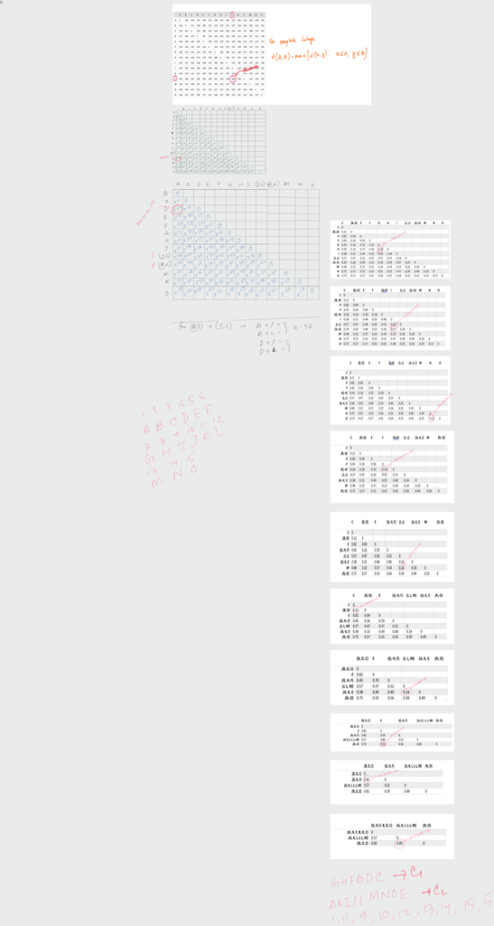

[figure not shown]

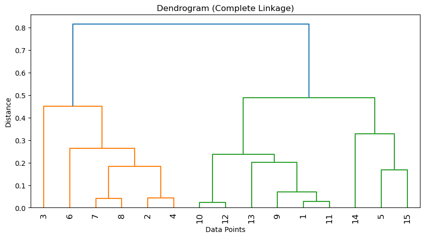

```python
# Validity check
import scipy.cluster.hierarchy as sch

# Given data points
data = np.array([
    [2.19, 1.06],
    [2.45, 1.02],
    [2.48, 1.23],
    [2.42, 1.05],
    [1.82, 0.75],
    [2.38, 0.79],
    [2.51, 0.89],
    [2.50, 0.93],
    [2.14, 1.05],
    [1.99, 0.95],
    [2.21, 1.04],
    [2.00, 0.93],
    [2.17, 0.86],
    [2.10, 0.58],
    [1.98, 0.70]
])

# Perform hierarchical clustering using complete linkage
linkage_matrix = sch.linkage(data, method='complete')

# Plot the dendrogram
plt.figure(figsize=(10, 5))
sch.dendrogram(linkage_matrix, labels=np.arange(1, 16), leaf_rotation=90)
plt.title("Dendrogram (Complete Linkage)")
plt.xlabel("Data Points")
plt.ylabel("Distance")
plt.show()
```

### Task 1.1.4 (3 points)

A) **[Compute by hand]** the density-based clustering DBSCAN for the dataset of Task 1.1.1 using $\epsilon=0.2$ and $MinPts=3$. Present at least 2 iterations of the algorithm

**YOUR ANSWER HERE**

**We label the points first**

P1 to P15 as there is 15 points.

**Iteration 1:**

Now, we need to calculate the Euclidean distance from the any non-visited point to all other points. Below is the table:

$ED = \sqrt{(x1-x2)^2 + (y1-y2)^2}$

$ED (P1, P2) = \sqrt{(2.19-2.45)^2 + (1.06-1.02)^2} = 0.263$

| Point | X | Y | Distance_from_P1 |
| --- | --- | --- | --- |
| P1 | 2.19 | 1.06 | 0.000 |
| P2 | 2.45 | 1.02 | 0.263 |
| P3 | 2.48 | 1.23 | 0.336 |
| P4 | 2.42 | 1.05 | 0.230 |
| P5 | 1.82 | 0.75 | 0.483 |
| P6 | 2.38 | 0.79 | 0.330 |
| P7 | 2.51 | 0.89 | 0.362 |
| P8 | 2.50 | 0.93 | 0.336 |
| P9 | 2.14 | 1.05 | 0.051 |
| P10 | 1.99 | 0.95 | 0.228 |
| P11 | 2.21 | 1.04 | 0.028 |
| P12 | 2.00 | 0.93 | 0.230 |
| P13 | 2.17 | 0.86 | 0.201 |
| P14 | 2.10 | 0.58 | 0.488 |
| P15 | 1.98 | 0.70 | 0.417 |

By observing the above table we can say **P1 is a Core point** because its $\epsilon$-neighbours {P9, P11} < $\epsilon = 0.2$, So that P1 has 2 neighbours + itself = 3 >= MinPts 3.

Again, we need to compute the ED from P2 to all other points.

However, we can also check whether **P9 is a core point or not?** Then we need to calculate the distance of P9 to all other points and merge it in one cluster.

**Iteration 2:**

$ED (P9, P2) = \sqrt{(2.14-2.45)^2 + (1.05-1.02)^2} = 0.311$

| Point | X | Y | Distance_from_P9 |
| --- | --- | --- | --- |
| P1 | 2.19 | 1.06 | 0.051 |
| P2 | 2.45 | 1.02 | 0.311 |
| P3 | 2.48 | 1.23 | 0.385 |
| P4 | 2.42 | 1.05 | 0.280 |
| P5 | 1.82 | 0.75 | 0.439 |
| P6 | 2.38 | 0.79 | 0.354 |
| P7 | 2.51 | 0.89 | 0.403 |
| P8 | 2.50 | 0.93 | 0.379 |
| P9 | 2.14 | 1.05 | 0.000 |
| P10 | 1.99 | 0.95 | 0.180 |
| P11 | 2.21 | 1.04 | 0.071 |
| P12 | 2.00 | 0.93 | 0.184 |
| P13 | 2.17 | 0.86 | 0.192 |
| P14 | 2.10 | 0.58 | 0.472 |
| P15 | 1.98 | 0.70 | 0.385 |

By observing the above table we can say **P9 is a Core point** because its $\epsilon$-neighbours {P1, P10, P11, P12, P13} < $\epsilon = 0.2$, So that P9 has 5 neighbours + itself = 6 >= MinPts 3.

**Observation:**

- Now, expand: for each neighbor (e.g., P11), check if it is core.
- Those neighbors (P11, P12, P13) are also either core or border, so they join the cluster. This chain continues until no new points can be added.
- C1 = {P1, P9, P10, P11, P12, P13}.
- C2 = {P2, P3, P4, P6, P7, P8}
- C3 = {P5, P14, P15}
- There is **no noise** in the data.

| Point | Coordinates | Cluster | Type |
| --- | --- | --- | --- |
| P1 | (2.19, 1.06) | 1 | CORE |
| P2 | (2.45, 1.02) | 2 | CORE |
| P3 | (2.48, 1.23) | 2 | BORDER |
| P4 | (2.42, 1.05) | 2 | CORE |
| P5 | (1.82, 0.75) | 3 | BORDER |
| P6 | (2.38, 0.79) | 2 | CORE |
| P7 | (2.51, 0.89) | 2 | CORE |
| P8 | (2.50, 0.93) | 2 | CORE |
| P9 | (2.14, 1.05) | 1 | CORE |
| P10 | (1.99, 0.95) | 1 | CORE |
| P11 | (2.21, 1.04) | 1 | CORE |
| P12 | (2.00, 0.93) | 1 | CORE |
| P13 | (2.17, 0.86) | 1 | CORE |
| P14 | (2.10, 0.58) | 3 | BORDER |
| P15 | (1.98, 0.70) | 3 | CORE |

```
Point Index | Coordinates        | Cluster Label | Type
--------------------------------------------------------
         0 | [2.19 1.06] |             0 | CORE
         1 | [2.45 1.02] |             1 | CORE
         2 | [2.48 1.23] |             1 | BORDER
         3 | [2.42 1.05] |             1 | CORE
         4 | [1.82 0.75] |             2 | BORDER
         5 | [2.38 0.79] |             1 | CORE
         6 | [2.51 0.89] |             1 | CORE
         7 | [2.5  0.93] |             1 | CORE
         8 | [2.14 1.05] |             0 | CORE
         9 | [1.99 0.95] |             0 | CORE
        10 | [2.21 1.04] |             0 | CORE
        11 | [2.   0.93] |             0 | CORE
        12 | [2.17 0.86] |             0 | CORE
        13 | [2.1  0.58] |             2 | BORDER
        14 | [1.98 0.7 ] |             2 | CORE
```

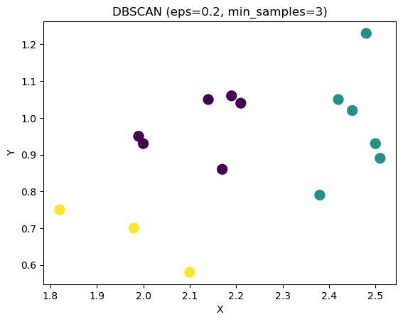

```python
# Checking the validity of our answer
from sklearn.cluster import DBSCAN

data = np.array([
    [2.19, 1.06],
    [2.45, 1.02],
    [2.48, 1.23],
    [2.42, 1.05],
    [1.82, 0.75],
    [2.38, 0.79],
    [2.51, 0.89],
    [2.50, 0.93],
    [2.14, 1.05],
    [1.99, 0.95],
    [2.21, 1.04],
    [2.00, 0.93],
    [2.17, 0.86],
    [2.10, 0.58],
    [1.98, 0.70]
])


# eps=0.2 (radius), min_samples=3 (i.e., at least 3 points in neighborhood to be core)
dbscan = DBSCAN(eps=0.2, min_samples=3)
labels = dbscan.fit_predict(data)

core_sample_indices = dbscan.core_sample_indices_
core_samples_mask = np.zeros_like(labels, dtype=bool)
core_samples_mask[core_sample_indices] = True

print("Point Index | Coordinates        | Cluster Label | Type")
print("--------------------------------------------------------")

for i, point in enumerate(data):
    cluster_label = labels[i]

    if cluster_label == -1:
        print(f"{i:10d} | {point} | {cluster_label:13d} | NOISE")
    else:
        if core_samples_mask[i]:
            print(f"{i:10d} | {point} | {cluster_label:13d} | CORE")
        else:
            print(f"{i:10d} | {point} | {cluster_label:13d} | BORDER")

plt.scatter(data[:, 0], data[:, 1], c=labels, cmap="viridis", s=100)
plt.title("DBSCAN (eps=0.2, min_samples=3)")
plt.xlabel("X")
plt.ylabel("Y")
plt.show()
```

B) **[Motivate]** the difference between the clusters obtained with DBSCAN and those obtained with KMeans in Task 1.1.1.

**YOUR ANSWER HERE**

The first and foremost difference is the cluster size. **KMeans** was forced to find exactly 2 clusters (since k=2), even though **DBSCAN** discovered 3 clusters naturally.

- **DBSCAN** (with the chosen $\epsilon$ and MinPts) and **Kmeans** identified no noise points for this particular data , but **DBSCAN** could have if some points lay in low-density regions.
- **KMeans** merges points together based on their distance to a centroid, whereas **DBSCAN** groups points that are close in “dense neighborhoods,” which can yield more organic, possibly elliptical or irregular shapes.
- If the dataset had **outliers**, **KMeans** would forcibly assign them to the nearest centroid, distorting that cluster. **DBSCAN**, by contrast, can explicitly label them as noise if they don’t belong to any dense region.

## Task 1.2 Elliptic data set (2 points)

**[Motivate]**  
After looking at the dataset *below*, you want to detect the red outlier point, assuming you know that it is an outlier.

Which approach would be the most obvious to find the red outlier? Please (1) check the box and (2) motivate your answer below:

- Distance based approach (with parameteres $\pi=0.5$, $\epsilon=2$ and euclidean distance)
- Angle based approach
- Depth based approach

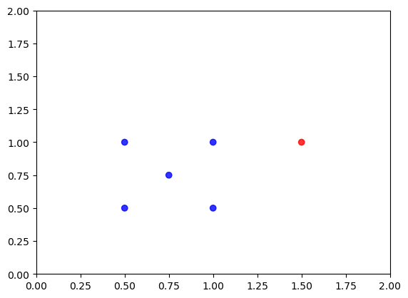

```python
D_new = np.array([[1.5, 1.0], # Red
                [1., 1.0],
                [0.5, 0.5],
                [1, 0.5],
                [0.5, 1],
                [0.75, 0.75]
                 ])

plt.scatter(D_new[:, 0], D_new[:, 1], alpha=0.8, c = ['red' if i == 0 else 'blue' for i in range(len(D_new))])
plt.axis([0, 2, 0, 2])
plt.show()
```

**YOUR ANSWER HERE**

**By observing the data, we can say that the depth based approach is suitable for the red outlier.**

**Depth-based is the most intuitive** because it looks at how centrally located each point is, and the red point is less “deep” (further from the main elliptical shape).

- Otherhand, **Angle-based** methods are useful in high-dimensional data where distances become less meaningful and angular separation can be more informative.
- Also, **Distance-based** with $\epsilon = 2$ likely will not flag the red point as outlier (the radius is too big).

## Task 1.3 Theoretical questions

### Task 1.3.1 Statistical Analysis (3 points)

**[Prove]** 1. Prove that the Euclidean distance is a pseudometric.

**YOUR ANSWER HERE**

**A distance is pseudometric if it follows:**

- **Positive Semidefinite:** $d(x,y) \ge 0$
- **Identity of indiscernibles (weak form)**: $d(x,x) = 0$, **without definite form, $d(x,y) = 0$, if $x = y$**
  - (Unlike a true metric, a pseudometric does *not* require $d(x,y) = 0, x = y$, it can be $x \neq y$
- **Symmetry:** $d(x,y) = d(y,x)$
- **Triangle Enequality:** $d(x, z) \le d(x,y) + d(y,z)$

Euclidean Distance = $\sqrt{\sum_{i=1}^n(x_i-y_i)^2}$

**1. Positive Semidefinite:** Each term $(x_i-y_i)^2 \ge 0$. Summing non-negative numbers is non-negative, and taking the square root preserves non-negativity. Hence:

$d(x,y) = \sqrt{\sum_{i=1}^n(x_i-y_i)^2} \ge 0$

**2. Identity of indiscernibles (weak form)**:

For any $x \in \mathbb{R}$,

$\sqrt{\sum_{i=1}^n(x-x)^2} = 0$

Thus $𝑑(𝑥,𝑥)=0 $. (Euclidean distance also satisfies the stronger condition $𝑑(𝑥,𝑦)=0 $ $⟺𝑥=𝑦$ , but for a pseudometric we only need $𝑑(𝑥,𝑥)=0d(x,x)=0.$). Therefore, it is not a requirement to follow $x = y$ it may also follow $x \neq y$. For this reason we can say every metric is also a pseudometric, but not every pseudometric is necessarily a metric.

**3. Symmetry:**

For any $x, y$, $d(x,y) = \sqrt{\sum_{i=1}^n(x_i-y_i)^2} = \sqrt{\sum_{i=1}^n(y_i-x_i)^2} = d(y,x)$

**4. Triangle Enequality:** For all $x, y, z \in X$, we can also write $d(x, z) \le d(x,y) + d(y,z)$ (Minkowski inequality for vectors in $\mathbb{R^n}$)

**[Prove]** 2. Prove that the sample mean is an unbiased estimator of the population mean.

**YOUR ANSWER HERE**

We want to show Sample mean$( \bar{X} )$ is an unbiased estimator of the population mean ($\mu$)

We know, mean $(\bar{X}) = \left(\frac{1}{n}\sum_{i=1}^n X_i\right)$

then $E(\bar{X}) = \mu$

**Expectation of the Sample Mean $( \bar{X} )$ (Plugin):**

$ E(\bar{X}) = E\left(\frac{1}{n}\sum_{i=1}^n X_i\right) $

**Linearity of Expectation:**

$ = \frac{1}{n} \sum_{i=1}^n E(X_i) $

**Since $( E(X_i) = \mu )$:**

$ = \frac{1}{n} \sum_{i=1}^n \mu $

**Simplify the Summation:**

$ = \frac{1}{n} \cdot n\mu \quad \text{(since \(\sum_{i=1}^n 1 = n\))} $

$ = \mu $

The sample mean $( \bar{X} )$ is an **unbiased estimator** of the population mean $( \mu )$.

**References:**

[1] Sample mean is unbiased estimator of population mean. ProofWiki. (n.d.). https://proofwiki.org/wiki/Sample_Mean_is_Unbiased_Estimator_of_Population_Mean#google_vignette

**[Prove]** 3. Prove that the sample variance is an asymptotically unbiased estimator of the population variance.

**YOUR ANSWER HERE**

we'll prove that the sample variance $S_n^2 = \frac{1}{n} \sum_{i=1}^n (X_i - \bar{X})^2$ is **asymptotically unbiased** for the population variance $\sigma^2$.

**1. Expand the Sample Variance**

expanding the squared term in $S_n^2$:

$$ \sum_{i=1}^n (X_i - \bar{X})^2 = \sum_{i=1}^n X_i^2 - 2\bar{X} \sum_{i=1}^n X_i + n\bar{X}^2 $$

Since $\sum_{i=1}^n X_i = n\bar{X}$, substitute this into the equation:

$$ \sum_{i=1}^n X_i^2 - 2n\bar{X}^2 + n\bar{X}^2 = \sum_{i=1}^n X_i^2 - n\bar{X}^2 $$

Thus, the sample variance becomes:

$$ S_n^2 = \frac{1}{n} \sum_{i=1}^n X_i^2 - \bar{X}^2 $$

**3. Plugin Expectation**

To find $\mathbb{E}[S_n^2]$, we take expectations of both terms:

**Term 1:** $\frac{1}{n} \sum_{i=1}^n X_i^2$

$$ \mathbb{E}\left[\frac{1}{n} \sum_{i=1}^n X_i^2\right] = \frac{1}{n} \sum_{i=1}^n \mathbb{E}[X_i^2] $$

By definition, $\mathbb{E}[X_i^2] = \text{Var}(X_i) + (\mathbb{E}[X_i])^2 = \sigma^2 + \mu^2$

Therefore:

$$ \mathbb{E}\left[\frac{1}{n} \sum_{i=1}^n X_i^2\right] = \frac{1}{n} \cdot n(\sigma^2 + \mu^2) = \sigma^2 + \mu^2 $$

**Term 2:** $\mathbb{E}[\bar{X}^2]$

First, note that $\bar{X}$ is the sample mean:

$$ \mathbb{E}[\bar{X}^2] = \text{Var}(\bar{X}) + (\mathbb{E}[\bar{X}])^2 $$

- $\mathbb{E}[\bar{X}] = \mu$
- $\text{Var}(\bar{X}) = \frac{\sigma^2}{n}$ (variance of the sample mean)

Thus:

$$ \mathbb{E}[\bar{X}^2] = \frac{\sigma^2}{n} + \mu^2 $$

**3. Combine the Results**

Now subtract the expectation of Term 2 from Term 1:

$$ \mathbb{E}[S_n^2] = \left(\sigma^2 + \mu^2\right) - \left(\frac{\sigma^2}{n} + \mu^2\right) = \sigma^2 - \frac{\sigma^2}{n} $$

Simplify:

$$ \mathbb{E}[S_n^2] = \sigma^2 \left(1 - \frac{1}{n}\right) $$

**4. Set the Limit as** $n \to \infty$

As the sample size $n$ grows large, the term $\frac{\sigma^2}{n}$ vanishes:

$$ \lim_{n \to \infty} \mathbb{E}[S_n^2] = \lim_{n \to \infty} \sigma^2 \left(1 - \frac{1}{n}\right) = \sigma^2 $$

Thus, $S_n^2$ is **asymptotically unbiased** for $\sigma^2$.

**5. Observations**

- **Bias in finite samples**: For finite $n$, $\mathbb{E}[S_n^2] = \sigma^2 - \frac{\sigma^2}{n}$, so $S_n^2$ underestimates $\sigma^2$. This is why the **unbiased sample variance** uses $\frac{1}{n-1}$ instead of $\frac{1}{n}$.
- **Asymptotic behavior**: As $n \to \infty$, the adjustment $\frac{\sigma^2}{n}$ becomes negligible. The difference between $\frac{1}{n}$ and $\frac{1}{n-1}$ also vanishes:

$$ \lim_{n \to \infty} \frac{n}{n-1} = 1 $$

- The sample variance $S_n^2$ (with divisor $n$) is biased for finite $n$
- However, as $n \to \infty$, the bias $\frac{\sigma^2}{n} \to 0$, making $S_n^2$ asymptotically unbiased:

$$ {\lim_{n \to \infty} \mathbb{E}[S_n^2] = \sigma^2} $$

This result underpins the consistency and reliability of sample variance for large datasets.

The plot demonstrates how the biased estimator ($\frac{1}{n}$) approaches the true population variance as $n$ increases, confirming its asymptotic unbiasedness.

**References:**

[2] Variance estimation. (n.d.). Statlect. https://www.statlect.com/fundamentals-of-statistics/variance-estimation

‌

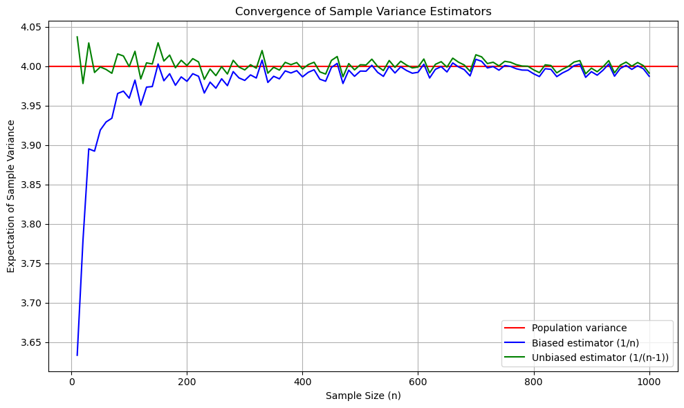

```python
# Checking the validity
import matplotlib.pyplot as plt

# Set random seed for reproducibility
np.random.seed(42)

# Population parameters
mu = 5
sigma = 2

# Sample sizes to test
sample_sizes = np.arange(10, 1001, 10)
num_simulations = 1000

# Arrays to store results
biased_variance_means = []
unbiased_variance_means = []

for n in sample_sizes:
    biased_variances = []
    unbiased_variances = []

    for _ in range(num_simulations):
        # Generate random sample from normal distribution
        sample = np.random.normal(mu, sigma, size=n)

        # Calculate biased and unbiased sample variances
        biased_var = np.sum((sample - np.mean(sample))**2) / n
        unbiased_var = np.sum((sample - np.mean(sample))**2) / (n - 1)

        biased_variances.append(biased_var)
        unbiased_variances.append(unbiased_var)

    # Store the mean of all simulations for this sample size
    biased_variance_means.append(np.mean(biased_variances))
    unbiased_variance_means.append(np.mean(unbiased_variances))

# Plot the results
plt.figure(figsize=(10, 6))
plt.axhline(y=sigma**2, color='r', linestyle='-', label='Population variance')
plt.plot(sample_sizes, biased_variance_means, 'b-', label='Biased estimator (1/n)')
plt.plot(sample_sizes, unbiased_variance_means, 'g-', label='Unbiased estimator (1/(n-1))')
plt.xlabel('Sample Size (n)')
plt.ylabel('Expectation of Sample Variance')
plt.title('Convergence of Sample Variance Estimators')
plt.legend()
plt.grid(True)
plt.tight_layout()
plt.show()
```

### Task 1.3.2 Kernel trick (7 points)

**[Motivation]** A) What is a positive-definite kernel $K(x,x')$ of two vectors $x,x'\in\mathbb{R}^n$.

**YOUR ANSWER HERE**

A positive definite kernel $K(x,x')$ of two vectors $x,x'\in\mathbb{R}^n$ is a symmetric function that satisfies the following properties:

- **Symmetry:** $K(x,x') = K(x', x)$ for $\forall (x, x') \in\mathbb{R}^n$
- **Positive Semi-definite:** For any finite set of vectors ${x_1, x_2, \dots, x_m} \subset \mathbb{R}^n$ and any real coefficients ${c_1, c_2, \dots, c_m} \subset \mathbb{R}$, $$\sum_{i=1}^m \sum_{j=1}^m c_i c_j K(x_i, x_j) \geq 0.$$ Equivalently, the Kernel $\mathbf{K}$, defined as $\mathbf{K}_{ij} = K(x_i, x_j)$, must be positive semi-definite (i.e., all eigenvalues of $\mathbf{K}$ are non-negative). **$c^{\top}Kc$**

**Usages**

- Enable kernel trick in SVM to implicitly compute high-dimensional features.
- Ensure optimization problems
- Guarantee mathematical consistency in similarity-based algorithms.
- Allow for nonlinear decision boundaries in otherwise linear classification methods.

**[Motivate]** B) Please explain briefly what is the kernel trick method.

**YOUR ANSWER HERE**

The **kernel trick** is a mathematical technique to apply linear algorithms to non-linearly separable data by implicitly mapping the input data into a higher-dimensional space.

**Best for**

- Computational Efficiency: Kernels compute inner products in high dimensions without explicitly constructing the high-dimensional space.
- Flexibility: Use any positive-definite kernel to model complex relationships.
- Non-Linear Decision Boundaries: Enables linear methods to solve non-linear problems.

**ex: Support Vector Machines (SVM): Find non-linear decision boundaries.**

**[Prove]** C) Let two positive-definite kernels $K_1(x,x')$ and $K_2(x,x')$.  
Show that functions $K_1(x,x')+K_2(x,x')$ and $K_1(x,x')K_2(x,x')$ are also positive-definite kernels.

**YOUR ANSWER HERE**

To prove, $K_1(x,x')+K_2(x,x')$ and $K_1(x,x')K_2(x,x')$ are also positive-definite kernels, we have to verify *2* properties of positive kernel:

**1. Symmeetry:** The both notions (addition and multiplication) are symmetry by nature, as we can write $x + y = y + x$ and $x * y = y * x$

**2. Positive semi-definite:** For any finite set of vectors ${x_1, x_2, \dots, x_m} \subset \mathbb{R}^n$ and any real coefficients ${c_1, c_2, \dots, c_m} \subset \mathbb{R}$, $$\sum_{i=1}^m \sum_{j=1}^m c_i c_j K(x_i, x_j) \geq 0.$$

Then, for $$K_1(x, x') + K_2(x, x')$$

we can write: $$\sum_{i=1}^m \sum_{j=1}^m c_i c_j (K_1(x_i, x_j') + K_2(x_i, x_j'))$$

Again, for $$K_1(x, x') * K_2(x, x')$$

we can write: $$\sum_{i=1}^m \sum_{j=1}^m c_i c_j (K_1(x_i, x_j') * K_2(x_i, x_j'))$$

Thus, the both varifies those properties. Therefore, they are positive-definite kernels.

**[Prove]** D) Prove that $K(x,x')=e^{2 ln(x^{\top}x')-(x-x')^{\top}(x-x')}$ is a positive-definite kernel.

**YOUR ANSWER HERE**

To prove, $K(x,x')=e^{2 ln(x^{\top}x')-(x-x')^{\top}(x-x')}$, we need to check the 2 properties:

**1. Symmetry:** $K(x,x') = K(x', x)$ for $\forall (x, x') \in\mathbb{R}^n$

Here,

$K(x,x') = e^{2 ln(x^{\top}x') - (x-x')^{\top}(x-x')}$

$ = e^{ln(x^{\top}x')^2 - (x-x')^{\top}(x-x')}$

$ = (x^{\top}x')^2 - (x-x')^{\top}(x-x')$

Now, we can write: $ = (x'^{\top}x)^2 - (x'-x)^{\top}(x'-x)$, because $(x-x')^{\top}(x-x') = (x'-x)^{\top}(x'-x)$

Thus, $K(x,x') = K(x', x)$ **[symmetry].**

**2. Positive semi-definite:** $c^{\top}Kc \ge 0$

Here, $ln(x^{\top}x') > 0$, and the second term, $(x-x')^{\top}(x-x')$ is the squared Euclidean distance which is non-negetive. Thus $K(x,x')=e^{2 ln(x^{\top}x')-(x-x')^{\top}(x-x')}$ is positive-definite kernel.

# Part 2 Exploratory data analysis

In this section, you will perform preliminary analysis on your data. These preliminary analysis are useful to understand how the data behaves, before running complex algorithms.

```python
toy = df
data_np = toy.to_numpy()
headers = ['alcohol', 'malic_acid', 'ash', 'alcalinity_of_ash', 'magnesium','total_phenols', 'flavanoids', 'nonflavanoid_phenols',
       'proanthocyanins', 'color_intensity', 'hue','od280/od315_of_diluted_wines', 'proline', 'target']
X = data_np[:,3:]
y = data_np[:,11]
rows, cols = np.shape(X)
toy.head()
```

|  | alcohol | malic_acid | ash | alcalinity_of_ash | magnesium | total_phenols | flavanoids | nonflavanoid_phenols | proanthocyanins | color_intensity | hue | od280/od315_of_diluted_wines | proline | target |
| --- | --- | --- | --- | --- | --- | --- | --- | --- | --- | --- | --- | --- | --- | --- |
| 0 | 14.23 | 1.71 | 2.43 | 15.6 | 127.0 | 2.80 | 3.06 | 0.28 | 2.29 | 5.64 | 1.04 | 3.92 | 1065.0 | 0 |
| 1 | 13.20 | 1.78 | 2.14 | 11.2 | 100.0 | 2.65 | 2.76 | 0.26 | 1.28 | 4.38 | 1.05 | 3.40 | 1050.0 | 0 |
| 2 | 13.16 | 2.36 | 2.67 | 18.6 | 101.0 | 2.80 | 3.24 | 0.30 | 2.81 | 5.68 | 1.03 | 3.17 | 1185.0 | 0 |
| 3 | 14.37 | 1.95 | 2.50 | 16.8 | 113.0 | 3.85 | 3.49 | 0.24 | 2.18 | 7.80 | 0.86 | 3.45 | 1480.0 | 0 |
| 4 | 13.24 | 2.59 | 2.87 | 21.0 | 118.0 | 2.80 | 2.69 | 0.39 | 1.82 | 4.32 | 1.04 | 2.93 | 735.0 | 0 |

```python
df.corr()
```

|  | alcohol | malic_acid | ash | alcalinity_of_ash | magnesium | total_phenols | flavanoids | nonflavanoid_phenols | proanthocyanins | color_intensity | hue | od280/od315_of_diluted_wines | proline | target |
| --- | --- | --- | --- | --- | --- | --- | --- | --- | --- | --- | --- | --- | --- | --- |
| alcohol | 1.000000 | 0.094397 | 0.211545 | -0.310235 | 0.270798 | 0.289101 | 0.236815 | -0.155929 | 0.136698 | 0.546364 | -0.071747 | 0.072343 | 0.643720 | -0.328222 |
| malic_acid | 0.094397 | 1.000000 | 0.164045 | 0.288500 | -0.054575 | -0.335167 | -0.411007 | 0.292977 | -0.220746 | 0.248985 | -0.561296 | -0.368710 | -0.192011 | 0.437776 |
| ash | 0.211545 | 0.164045 | 1.000000 | 0.443367 | 0.286587 | 0.128980 | 0.115077 | 0.186230 | 0.009652 | 0.258887 | -0.074667 | 0.003911 | 0.223626 | -0.049643 |
| alcalinity_of_ash | -0.310235 | 0.288500 | 0.443367 | 1.000000 | -0.083333 | -0.321113 | -0.351370 | 0.361922 | -0.197327 | 0.018732 | -0.273955 | -0.276769 | -0.440597 | 0.517859 |
| magnesium | 0.270798 | -0.054575 | 0.286587 | -0.083333 | 1.000000 | 0.214401 | 0.195784 | -0.256294 | 0.236441 | 0.199950 | 0.055398 | 0.066004 | 0.393351 | -0.209179 |
| total_phenols | 0.289101 | -0.335167 | 0.128980 | -0.321113 | 0.214401 | 1.000000 | 0.864564 | -0.449935 | 0.612413 | -0.055136 | 0.433681 | 0.699949 | 0.498115 | -0.719163 |
| flavanoids | 0.236815 | -0.411007 | 0.115077 | -0.351370 | 0.195784 | 0.864564 | 1.000000 | -0.537900 | 0.652692 | -0.172379 | 0.543479 | 0.787194 | 0.494193 | -0.847498 |
| nonflavanoid_phenols | -0.155929 | 0.292977 | 0.186230 | 0.361922 | -0.256294 | -0.449935 | -0.537900 | 1.000000 | -0.365845 | 0.139057 | -0.262640 | -0.503270 | -0.311385 | 0.489109 |
| proanthocyanins | 0.136698 | -0.220746 | 0.009652 | -0.197327 | 0.236441 | 0.612413 | 0.652692 | -0.365845 | 1.000000 | -0.025250 | 0.295544 | 0.519067 | 0.330417 | -0.499130 |
| color_intensity | 0.546364 | 0.248985 | 0.258887 | 0.018732 | 0.199950 | -0.055136 | -0.172379 | 0.139057 | -0.025250 | 1.000000 | -0.521813 | -0.428815 | 0.316100 | 0.265668 |
| hue | -0.071747 | -0.561296 | -0.074667 | -0.273955 | 0.055398 | 0.433681 | 0.543479 | -0.262640 | 0.295544 | -0.521813 | 1.000000 | 0.565468 | 0.236183 | -0.617369 |
| od280/od315_of_diluted_wines | 0.072343 | -0.368710 | 0.003911 | -0.276769 | 0.066004 | 0.699949 | 0.787194 | -0.503270 | 0.519067 | -0.428815 | 0.565468 | 1.000000 | 0.312761 | -0.788230 |
| proline | 0.643720 | -0.192011 | 0.223626 | -0.440597 | 0.393351 | 0.498115 | 0.494193 | -0.311385 | 0.330417 | 0.316100 | 0.236183 | 0.312761 | 1.000000 | -0.633717 |
| target | -0.328222 | 0.437776 | -0.049643 | 0.517859 | -0.209179 | -0.719163 | -0.847498 | 0.489109 | -0.499130 | 0.265668 | -0.617369 | -0.788230 | -0.633717 | 1.000000 |

## Task 2.1 Correlation matrix

### Task 2.1.1 (5 points)

A) **[Implement]** in the code-box below the **correlation matrix** (not covariance matrix) among all the attributes.  
To CHECK your results you can use **numpy.corrcoef**.

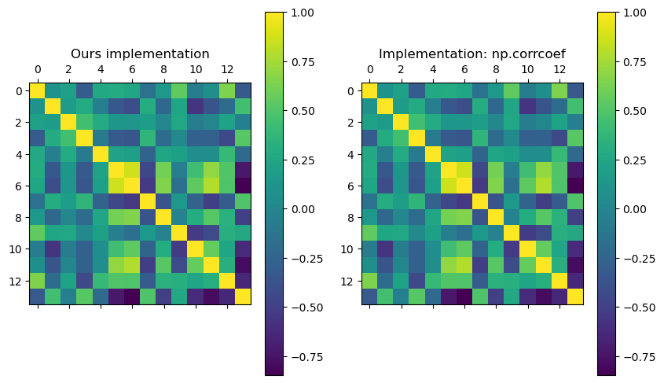

```python
def correlation_matrix(X):
    corr = None
    # YOUR CODE HERE
    X = X.astype(float)

    num_vars = len(X[0])
    n = len(X)
    corr = np.zeros((num_vars, num_vars))

    for i in range (num_vars):
        for j in range (num_vars):
            mean_i = np.mean(X[:, i])
            mean_j = np.mean(X[:, j])
            numerator = np.sum((X[:, i] - mean_i) * (X[:, j] - mean_j))
            denominator = np.sqrt(np.sum((X[:, i] - mean_i)**2) * np.sum((X[:, j] - mean_j)**2))
            corr [i, j] = numerator/denominator

    # YOUR CODE HERE
    return corr

X = data_np
Corr = correlation_matrix(X)
#validity with corrcoef
c = np.corrcoef(X, rowvar=False)

plt.figure(figsize=(10, 6))
plt.subplot(121)
plt.title("Ours implementation")
plt.matshow(Corr, fignum=0)
plt.colorbar()

#validity
plt.subplot(122)
plt.title("Implementation: np.corrcoef")
plt.matshow(c, fignum=0)
plt.colorbar()
plt.show()
```

**[Motivate]**  
B) By observing the **correlation matrix** in A), which pair(s) of different features has the highest correlation?

**YOUR ANSWER HERE**

By observing the above heatmap, we can see that **`total_phenols` and `flavanoids`** has the highest correlation.

Then, **`flavanoids` and `dialuted_wines`**

and then **`total_phenols` and `dialuted_wines`**

**[Motivate]**  
C) What does it mean that two features are highly correlated?

**YOUR ANSWER HERE**

When two features are **highly correlated,** it means there is a **strong linear relationship** between them. Their values tend to change together in a predictable way, either in the same direction (positive correlation) or opposite directions (negative correlation).

**[Motivate]**  
D) Based on the features of the data in Part 2 and your answer in C), did you expect the observation of B)?

**YOUR ANSWER HERE**

Here, we can see that the **`total_phenols`** has a strong correlation with **`flavanoids`** and with the increase of one affects another. Also they hold positive correlation.

```python
toy.iloc[:5,5:7]
```

|  | total_phenols | flavanoids |
| --- | --- | --- |
| 0 | 2.80 | 3.06 |
| 1 | 2.65 | 2.76 |
| 2 | 2.80 | 3.24 |
| 3 | 3.85 | 3.49 |
| 4 | 2.80 | 2.69 |

### Task 2.1.2 (2 points)

**[Motivate]**

Plot the correlation matrix running the code below. (You may need to zoom on it) What is the relationship between the correlation matrix and the covariance matrix? (1) Check the correct box below and (2) motivate your answer.

- The correlation matrix contains the unnormalized covariance values
- The correlation matrix contains the normalized covariance values
- The covariance matrix contains the variance of the correlation

Do NOT just choose an answer. Please clarify WHY this is the correct answer.

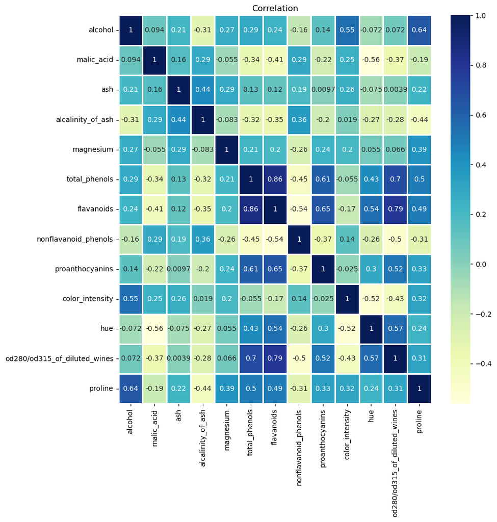

```python
df_to_plot = df.drop(['target'],axis=1)

fig, ax = plt.subplots(figsize=(10,10))
sns.heatmap(df_to_plot.corr(),annot=True,linewidths=1, cmap="YlGnBu", annot_kws={"fontsize":10}, vmax=1, ax=ax)
plt.title('Correlation')
plt.show()
```

**YOUR ANSWER HERE**

The **correlation matrix** contains the **normalized covarience** values by dividing the **standard deviations** of the variables. Though, This normalization removes the effect of variable scales, allowing for meaningful comparisons of relationship strengths across different pairs of features.

Formula:

$$Corr(x_i, x_j) = \frac{Cov(x_i, x_j)}{\sigma x_i \sigma x_j}$$

### Task 2.1.3 (3 points)

In this task, we reason about the covariance matrices.

**[Implement]** code for normalizing the features of the wine dataset using (1) standard score normalization and (2) range normalization. Finally, (3) plot the **covariance** matrices for

1. The unnormalized data
2. The [standard score normalized features](https://en.wikipedia.org/wiki/Standard_score)
3. The range (min-max) normalized features

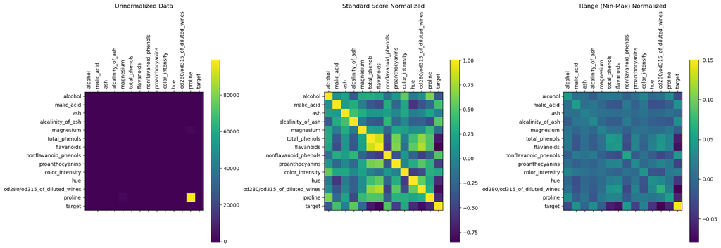

```python
# Data
X = data_np

# YOUR CODE HERE

# 1. Standard Score Normalization
X_sscore = (X - X.mean(axis=0)) / X.std(axis=0)

# 2. Range (Min-Max) Normalization
X_minmax = (X - X.min(axis=0)) / (X.max(axis=0) - X.min(axis=0))

# Compute covariance matrices
cov_unnormalized = np.cov(X, rowvar=False)
cov_sscore = np.cov(X_sscore, rowvar=False)
cov_minmax = np.cov(X_minmax, rowvar=False)

# Plot covariance matrices
fig, axes = plt.subplots(1, 3, figsize=(20, 7))

titles = ["Unnormalized Data", "Standard Score Normalized", "Range (Min-Max) Normalized"]
cov_matrices = [cov_unnormalized, cov_sscore, cov_minmax]

for ax, title, cov in zip(axes, titles, cov_matrices):
    im = ax.matshow(cov)
    ax.set_title(title)
    ax.set_xticks(np.arange(len(headers)))
    ax.set_yticks(np.arange(len(headers)))
    ax.set_xticklabels(headers, rotation=90)
    ax.set_yticklabels(headers)
    plt.colorbar(im, ax=ax)

plt.tight_layout()
plt.show()
# YOUR CODE HERE
```

### Task 2.1.4 (2 points)

**[Motivate]** how the covariance matrix changes with different normalization schemes and reason on why such behaviour appears. You should notice some differences. (1) Check the correct box below and (2) motivate your answer.

- Range normalization preserves the variance. Therefore, features are directly comparable within the matrix.
- Standard score normalization preserves the variance. Therefore, features are directly comparable within the matrix.
- Both methods normalize in such a way, that it makes sense to compare the different covariance values to each other within the matrix.
- None of the methods normalize in such a way that it makes sense to compare the different covariance values to each other.

Do NOT just choose an answer. Please clarify WHY this is the correct answer.

**YOUR ANSWER HERE**

**Standard Score** preserves the relative relationships (correlations) between features while standardizing variances to 1. Moreover, covariance values become scale-invariant (correlations), enabling meaningful comparisons.

**Range Normalization** does not preserve variance or covariance relationships. Besides, covariance magnitudes depend on the original feature scales, making comparisons invalid.

## Task 2.2 Normal distribution

### Task 2.2.1 (4 points)

Sometimes it is convenient to know whether a variable is close to a normal distribution.

**[Implement]** a method norm_dist that:

1. **Inputs**:
   - the number of buckets $b$
   - a vector $x$ of values
2. First, compute the histogram of a Gaussian variable with mean $\mu$ corresponding to the sample mean of $x$ and $\sigma^2$ corresponding to the sample variance of $x$. Second, calculate the histogram of $x$ using $b$ buckets.
3. **Output**: the sum of the absolute differences of the buckets between the two histograms computed in 2). The sum of the differences is computed as $$\sum_{i=1}^b |H_X(i) - H_{\mathcal{N}}(i)|$$ where $H_X(i)$ is the i-th bucket of the histogram of $x$ and $H_\mathcal{N}(i)$ is the i-th bucket of the hisotgram obtained from the normal distribution $\mathcal{N}(\mu,\sigma^2)$.

You can use the norm function from Scipy to get the normal distribution to subtract from.

```python
from scipy.stats import norm

## Our data comes from the variable X
X = data_np

def norm_dist(x, b):
    dist = 0
    ### YOUR CODE HERE
    mu = np.mean(x)
    sigma = np.std(x, ddof=1)
    n = len(x)
    min_val = np.min(x)
    max_val = np.max(x)
    bins = np.linspace(min_val, max_val, b + 1)
    H_x, _ = np.histogram(x, bins=bins)
    H_N = np.zeros(b)
    for i in range(b):
        left = bins[i]
        right = bins[i+1]
        prob = norm.cdf(right, mu, sigma) - norm.cdf(left, mu, sigma)
        H_N[i] = prob * n

    dist = np.sum(np.abs(H_x - H_N))
    ### YOUR CODE HERE
    return dist
```

### Task 2.2.2 (6 point)

A) **[Motivate]** which drawbacks the method in Task 2.2.1 has.

**YOUR ANSWER HERE**

The above method has sevarel drawbacks, one of them is **Bin size sensitivity** of the histogram.

- If we take few bins, we can get very coarse histogram.
- If we take larger bins, we can get unstable estimates with few points.

Also, the sum-of-absolute-differences with a matching normal histogram is a simple, heuristic measure.

B) **[Motivate]** whether the method in Task 2.2.1 is robust to outliers.

**YOUR ANSWER HERE**

**Robustness** means a method does not change drastically when **outliers** appear in data. However, the above method is not robust for detecting outlier because it relies on the sample mean and variance which are sensitive in this case, and also uses a histogram that can be skewed by extreme points.

**[Implement]**  
C) Run your code on each columns of the dataset.

```python
# YOUR CODE HERE
b = 10
results = []

for i in range(X.shape[1]):
    feature_col = X[:, i]

    # Compute sum of abs diffs with 10 bins
    dist_val = norm_dist(feature_col, b)

    # Save (feature_name, distance_value) in a list
    results.append((headers[i], dist_val))

# Sort by ascending distance (small to large)
results.sort(key=lambda tup: tup[1])

print(f"Feature                           | Sum-of-abs-diffs (b={b})")
print("----------------------------------------------------------")
for name, val in results:
    print(f"{name:33s} | {val:.4f}")

# YOUR CODE HERE
```

```
Feature                           | Sum-of-abs-diffs (b=10)
----------------------------------------------------------
proanthocyanins                   | 27.6007
alcalinity_of_ash                 | 29.2280
ash                               | 30.6465
hue                               | 32.6044
magnesium                         | 38.7020
color_intensity                   | 46.8710
alcohol                           | 49.1275
total_phenols                     | 50.0232
nonflavanoid_phenols              | 50.6867
flavanoids                        | 60.2123
od280/od315_of_diluted_wines      | 75.3731
proline                           | 75.6670
malic_acid                        | 84.5867
target                            | 247.4983
```

**[Motivate]**  
D) What is the column with the largest distance?

**YOUR ANSWER HERE**

**malic_acid** has the largest distance. Though if we consider target as a feature then it is showing highest.

**[Motivate]**  
E) Do the features follow a normal distribution?

**YOUR ANSWER HERE**

**A larger sum-of-absolute-differences = 84.5867** means that, when we compare the histogram of **“malic_acid”** to the histogram of a normal distribution with the same mean and variance, they differ significantly in one or more bins. Although, there could be skewness, heavy tails. Additionally, **target column also has the highest sum of absolute difference.**

### Task 2.2.3 (2 points)

Now look at the method below. This is called a Quantile-Quantile [Q-Q plot](https://en.wikipedia.org/wiki/Q%E2%80%93Q_plot).

**[Motivate]** why this method is more robust than the one we proposed in Task 2.2.1.

```
['alcohol', 'malic_acid', 'ash', 'alcalinity_of_ash', 'magnesium', 'total_phenols', 'flavanoids', 'nonflavanoid_phenols', 'proanthocyanins', 'color_intensity', 'hue', 'od280/od315_of_diluted_wines', 'proline', 'target'] (178, 14)
```

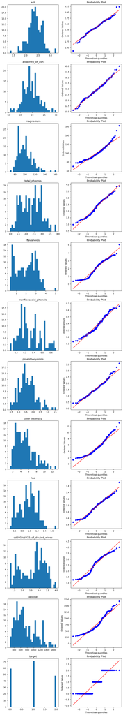

```python
from scipy import stats
from matplotlib import gridspec

plt.tight_layout()
_, n = X.shape
print(headers, X.shape)
fig = plt.figure(constrained_layout=True, figsize=(8, 50))
spec = gridspec.GridSpec(ncols=2, nrows=(n-1), figure=fig)
for i in np.arange(2,n):
    x = toy[headers[i]]
    r = i-1
    qq = fig.add_subplot(spec[r, 1])
    stats.probplot(x, plot=qq)
    h = fig.add_subplot(spec[r, 0])
    h.set_title(headers[i])
    h.hist(x, bins = 30)
```

**YOUR ANSWER HERE**

**Q-Q plots** are more robust primarily because they do not rely on histogram bins (which can be quite sensitive) and instead use a rank-based approach that keeps a point-by-point comparison of data vs. theoretical distribution. Moreover, Q-Q plot directly compares ordered data points to theoretical quantiles, with no binning involved so it avoids the pitfalls of histogram edges. Also, Q-Q plot can instantly reveal if our data is too skewed or heavy-tailed.

# Part 3 Cluster Analysis

In this section, you will perform cluster analysis of the dataset in Part 2 and modify clustering algorithms to achieve better results.

## Task 3.1

### Task 3.1.1 (6 points)

A) **[Implement]** and plot the **silhouette coefficient** to detect the number of clusters $k$.

You can use the KMeans implementation from scikit-learn.

```python
toy = df
first = "alcohol"
second = "flavanoids"
X = toy[[first, second]].to_numpy()
y = toy['target']
```

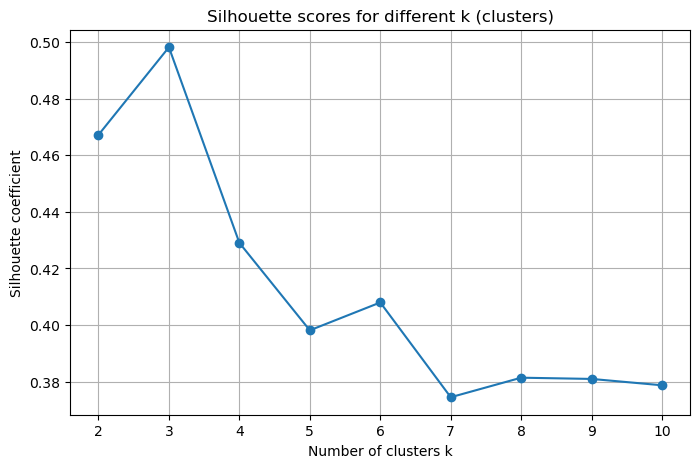

```
Best k = 3, with silhouette score = 0.4981
```

```python
# Data
X = toy[[first, second]].to_numpy()
### YOUR CODE HERE
from sklearn.metrics import silhouette_score
k_values = range(2, 11)  # 2 to 10
sil_scores = []

for k in k_values:
    # 1) Fit KMeans
    kmeans = KMeans(n_clusters=k, random_state=RANDOM_SEED)
    labels = kmeans.fit_predict(X)

    # 2) Compute silhouette
    score = silhouette_score(X, labels)
    sil_scores.append(score)

# Convert to array or just leave as list
sil_scores = np.array(sil_scores)
plt.figure(figsize=(8,5))
plt.plot(k_values, sil_scores, marker='o')
plt.title("Silhouette scores for different k (clusters)")
plt.xlabel("Number of clusters k")
plt.ylabel("Silhouette coefficient")
plt.xticks(k_values)
plt.grid(True)
plt.show()

best_k = k_values[np.argmax(sil_scores)]
best_score = np.max(sil_scores)
print(f"Best k = {best_k}, with silhouette score = {best_score:.4f}")
```

B) **[Motivate]** your choice of clusters $k$.

**YOUR ANSWER HERE**

Our choice of clusters **K = 3** because it has the highest silhouette score.

C) **[Implement]**  
Run k-means on the dataset X, with the number of clusters detected in the previous exercise.

You can use the KMeans implementation from scikit-learn.

```
[1 1 1 1 1 1 1 1 1 1 1 1 1 1 1 1 1 1 1 1 1 0 1 0 1 1 1 1 1 1 1 1 1 1 1 1 1
 1 1 1 1 1 1 1 1 1 1 1 1 1 1 1 1 1 1 1 1 1 1 2 2 2 2 0 0 0 1 0 2 0 2 1 2 1
 0 0 0 0 0 0 0 0 0 2 0 0 0 0 0 0 0 0 2 0 0 0 0 0 1 0 0 2 0 0 0 0 0 0 0 0 0
 0 0 0 0 0 0 0 2 0 0 1 0 1 0 0 0 0 0 0 2 2 2 2 2 2 2 2 2 2 2 2 2 2 2 2 2 2
 2 2 2 2 2 2 2 2 2 2 2 2 2 2 2 2 2 2 2 2 2 2 2 2 2 2 2 2 2 2]
```

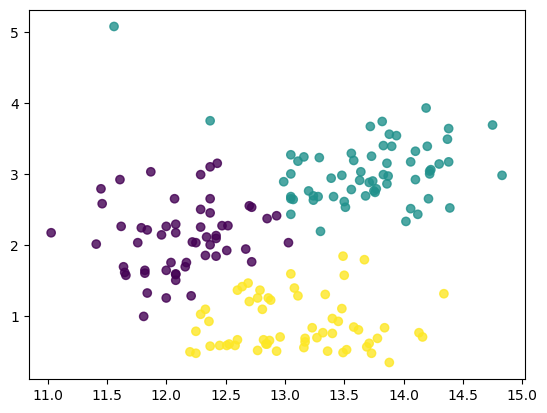

```python
# Data
X = toy[[first, second]].to_numpy()
### YOUR CODE HERE
k_means = KMeans(n_clusters=3, random_state=RANDOM_SEED).fit(X)
Cluster_labels =  k_means.labels_
print(Cluster_labels)
plt.scatter(toy[first], toy[second], alpha=0.8, c=Cluster_labels)
plt.show()
```

**[Motivate]** Did you find better clusters? Are they more separated? Why is it a good/bad idea to use the Silhouette coefficient?

**YOUR ANSWER HERE**

**Observations:**

- By looking at the scatter plot, the clusters are more separated (less overlap) and tighter within each color group.
- Hence, yes, we observe a higher silhouette score and the plot shows distinct groupings, we can say we have found “better” clusters.

**Pros:**

- Each point’s silhouette depends on how close it is to its own cluster versus the next-closest cluster. This gives a balanced measure of cluster quality.
- Silhouette is an unsupervised metric; it only uses the data and the cluster assignments—no external ground truth.

**Cons:**

- Computing silhouette for large datasets can be expensive.

### Task 3.1.2 (3 points)

**[Implement]** Kernel K-means and the Gaussian Kernel.

The Gaussian kernel is defined as in the following equation:

$$ K\left(\mathbf{x}_{i}, \mathbf{x}_{j}\right)=\exp \left(-\frac{\left\|\mathbf{x}_{i}-\mathbf{x}_{j}\right\|^{2}}{2 \sigma^{2}}\right)$$

```python
X = df[['malic_acid', "magnesium"]].to_numpy()
X_norm = (X - X.min(axis=0)) / np.ptp(X, axis=0)
X_scaled = StandardScaler().fit(X_norm).transform(X_norm)

y = df[['target']].to_numpy()



def gaussian_kernel(x, y, sigma=0.2):
    return np.exp(-np.sum((x - y) ** 2) / (2 * sigma ** 2))

def kernel_kmeans(X, n_clusters, kernel=gaussian_kernel, iters=100, error=0):
    kmeans = KMeans(n_clusters=n_clusters, init="k-means++", max_iter=1, random_state=RANDOM_SEED).fit(X)
    clusters = kmeans.labels_.copy()

    n_samples = X.shape[0]
    K = np.zeros((n_samples, n_samples))

    # Compute Kernel Matrix
    for i in range(n_samples):
        for j in range(n_samples):
            K[i, j] = kernel(X[i], X[j])

    prev_clusters = np.full(n_samples, -1)  # Track previous cluster assignments

    for _ in range(iters):
        cluster_sums = np.zeros((n_clusters, n_samples))
        cluster_sizes = np.zeros(n_clusters)

        for i in range(n_samples):
            cluster_sums[clusters[i]] += K[i]
            cluster_sizes[clusters[i]] += 1

        for j in range(n_clusters):
            if cluster_sizes[j] > 0:
                cluster_sums[j] /= cluster_sizes[j]  # Normalize cluster centers

        # Compute new cluster assignments
        distances = np.zeros((n_samples, n_clusters))
        for j in range(n_clusters):
            if cluster_sizes[j] > 0:
                distances[:, j] = np.diag(K) - 2 * cluster_sums[j] + np.mean(K[clusters == j])
            else:
                distances[:, j] = np.inf  # Prevent empty cluster assignment

        new_clusters = np.argmin(distances, axis=1)

        # Check for convergence
        if np.linalg.norm(new_clusters - prev_clusters) <= error:
            break
        prev_clusters = new_clusters.copy()
        clusters = new_clusters.copy()

    return clusters
```

### Task 3.1.3 (3 points)

**[Motivate]** Run both kmeans and kernel K-means on the data. Which clustering do you think is better and explain why do you think so? Which one most resemble the ground truth labeling? Under which condition is Kernel K-means with Gaussian Kernel better than K-means?

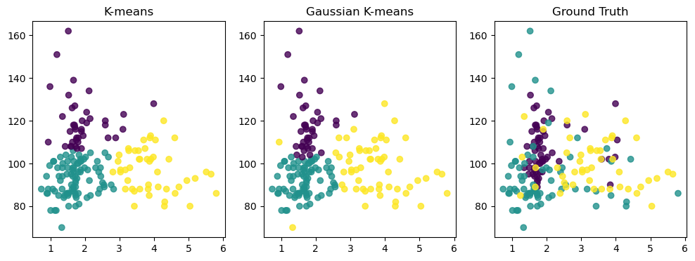

```python
kmeans_clustering = KMeans(n_clusters=3, random_state=RANDOM_SEED).fit(X_scaled).labels_
gaussian_clustering = kernel_kmeans(X_scaled, 3, kernel=gaussian_kernel)


fig, axes = plt.subplots(nrows=1, ncols=3, figsize=(12,4))
axes[0].scatter(X[:, 0], X[:, 1], alpha=0.8, c=kmeans_clustering)
axes[0].set_title("K-means")

axes[1].scatter(X[:, 0], X[:, 1], alpha=0.8, c=gaussian_clustering)
axes[1].set_title("Gaussian K-means")

axes[2].scatter(X[:, 0], X[:, 1], alpha=0.8, c=y)
axes[2].set_title("Ground Truth")
```

**YOUR ANSWER HERE**

**Observations:**

- Kernel K-Means with a well-chosen $\sigma$ can produce less color mixing if the data is not linearly separable.
- If we see, for instance, in the plots, the Gaussian method appears to handle the central region (where purple and teal classes overlap) somewhat more faithfully to reality.

**Under which condition Kernel K-means with Gaussian Kernel better than K-means**

- **Nonlinear Clusters:** Whenever the data’s true structure is not simply radial or elliptical, a kernel approach can discover more flexible boundaries.
- **Careful Choice of $\sigma$:** We need a good $\sigma$ value for the Gaussian kernel. Too large or too small can hamper performance.

### Task 3.1.4 (4 points)

**[Motivate]** Running the code below, draw two example datasets such that:  
a). K-means produces clustering better than the one obtained by Gaussian K-means.  
b). Gaussian K-means produces clustering better than the one obtained by Vanilla K-means.

Explain why do you think one clustering is better than the other and give the reason why K-means and Gaussian K-means behave this way.

```python
### You can use this tool to generate the data
from drawdata import ScatterWidget
widget = ScatterWidget()
```

```python
widget
```

```
ScatterWidget()
```

```python
### Run this code to print data from the tool above
if len(widget.data) != 0:
    data = widget.data_as_pandas[['x', 'y']][:400].to_numpy()
    print(np.array2string(data, precision=0, separator=',', ).replace('\n', ''))
```

[output not shown]

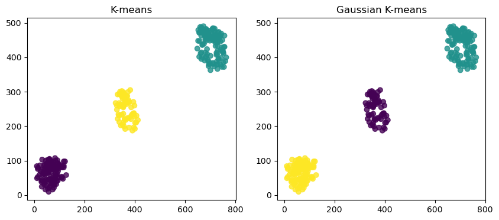

```python
### You can use this code for plotting. It's just a template you can modify it if you want to.

# Save your example dataset in the array below
X = np.array([])

# Use the line below for debugging, so that you don't have to copy paste data every time
X = widget.data_as_pandas[['x', 'y']].to_numpy()[:400]

X_norm = (X - X.min(axis=0)) / np.ptp(X, axis=0)
X_scaled = StandardScaler().fit(X_norm).transform(X_norm)

n_clusters = 2
kmeans_clustering = KMeans(n_clusters=3, random_state=2137).fit(X_scaled).labels_
gaussian_clustering = kernel_kmeans(X_scaled, n_clusters=3, kernel=gaussian_kernel)

fig, axes = plt.subplots(nrows=1, ncols=2, figsize=(10,4))
axes[0].scatter(X[:, 0], X[:, 1], alpha=0.8, c=kmeans_clustering)
axes[0].set_title(f"K-means")

axes[1].scatter(X[:, 0], X[:, 1], alpha=0.8, c=gaussian_clustering)
axes[1].set_title(f"Gaussian K-means")
```

```python
widget
```

```
ScatterWidget(data=[{'x': 66.67421322156552, 'y': 67.26369695065858, 'color': '#1f77b4', 'label': 'a'}, {'x': …
```

```python
### Run this code to print data from the tool above
if len(widget.data) != 0:
    data = widget.data_as_pandas[['x', 'y']][:400].to_numpy()
    print(np.array2string(data, precision=0, separator=',', ).replace('\n', ''))
```

[output not shown]

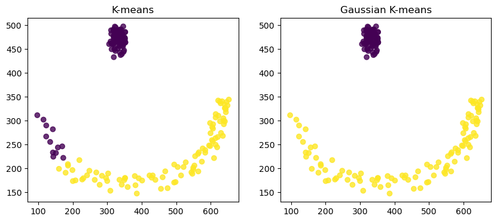

```python
### You can use this code for plotting. It's just a template you can modify it if you want to.

# Save your example dataset in the array below
X = np.array([])

# Use the line below for debugging, so that you don't have to copy paste data every time
X = widget.data_as_pandas[['x', 'y']].to_numpy()[:400]

X_norm = (X - X.min(axis=0)) / np.ptp(X, axis=0)
X_scaled = StandardScaler().fit(X_norm).transform(X_norm)

n_clusters = 2
kmeans_clustering = KMeans(n_clusters=n_clusters, random_state=2137).fit(X_scaled).labels_
gaussian_clustering = kernel_kmeans(X_scaled, n_clusters, kernel=gaussian_kernel)

fig, axes = plt.subplots(nrows=1, ncols=2, figsize=(10,4))
axes[0].scatter(X[:, 0], X[:, 1], alpha=0.8, c=kmeans_clustering)
axes[0].set_title(f"K-means")

axes[1].scatter(X[:, 0], X[:, 1], alpha=0.8, c=gaussian_clustering)
axes[1].set_title(f"Gaussian K-means")
```

**YOUR ANSWER HERE**

**Dataset A:**

- K‐Means is great for “blob” shaped data. It’ll produce a near‐optimal separation.
- Gaussian (kernel) K‐Means does fine or might overcomplicate it.

**Dataset B:**

## Task 3.2 Clustering quality

### Task 3.2.1 (2 points)

**[Implement]** **Normalized Mutual Information (NMI)** as a measure for clustering quality.

**Hint**: First implement **Entropy** and then **Normalized Mutual Information**.

```python
### C is the clustering obtained by an algorithm and T is the ground truth cluster assignments.
import math

def entropy(C):
    ### IMPLEMENT
    C = np.asarray(C)
    n = len(C)
    unique_labels, counts = np.unique(C, return_counts=True)

    prob = counts / n
    entropy = -np.sum(prob * np.log2(prob))
    return entropy


def NMI(C, T):
    ### IMPLEMENT
    C = np.asarray(C).ravel()
    T = np.asarray(T).ravel()
    n = len(C)
    if len(T) != n:
        raise ValueError("C and T must have the same length")

    # 1) entropies
    H_C = entropy(C)
    H_T = entropy(T)

    # 2) build contingency / confusion matrix for (C, T)
    unique_C = np.unique(C)
    unique_T = np.unique(T)
    confusion = np.zeros((len(unique_C), len(unique_T)), dtype=float)

    # map each label to an index
    c_to_idx = {label: idx for idx, label in enumerate(unique_C)}
    t_to_idx = {label: idx for idx, label in enumerate(unique_T)}

    # fill confusion
    for i in range(n):
        c_label = C[i]
        t_label = T[i]
        confusion[c_to_idx[c_label], t_to_idx[t_label]] += 1

    # 3) convert counts to probabilities
    p_ct = confusion / n  # shape (#C, #T)
    p_c = p_ct.sum(axis=1, keepdims=True)  # shape (#C,1)
    p_t = p_ct.sum(axis=0, keepdims=True)  # shape (1,#T)

    # mutual information I(C;T) = sum p(c,t)*log2( p(c,t)/(p(c)*p(t)) )
    I_CT = 0.0
    # small epsilon to avoid log(0)
    eps = 1e-12
    for c_idx in range(len(unique_C)):
        for t_idx in range(len(unique_T)):
            if p_ct[c_idx, t_idx] > 0:
                I_CT += p_ct[c_idx, t_idx] * np.log2(
                    (p_ct[c_idx, t_idx] + eps) / ((p_c[c_idx, 0] + eps) * (p_t[0, t_idx] + eps))
                )

    # 4) NMI with geometric mean
    denom = np.sqrt(H_C * H_T)
    if denom < 1e-12:
        return 1.0 if np.all(C == T) else 0.0

    nmi_val = I_CT / denom
    return nmi_val
```

Run the code below to measure the quality of clustering obtained by k-means in task 3.1.3.

```python
X = df[['malic_acid', "magnesium"]].to_numpy()
X_norm = (X - X.min(axis=0)) / np.ptp(X, axis=0)
y = df[['target']].to_numpy()


T = y # Ground-truth clusters
T = T.ravel()
#print(T.shape)
C = KMeans(n_clusters=3, random_state=RANDOM_SEED).fit_predict(X_norm)# Clusters obtained by k-means
#print(C.shape)


print(f'Normalized Mutual Information: {NMI(C, T)}')
```

```
Normalized Mutual Information: 0.1702087481846868
```

### Task 3.2.2 (4 points)

**[Motivate]**  
A) Reason about the measure, is the measure influenced by the size of the clusters?

**YOUR ANSWER HERE**

Yes, the measure is influenced by the size of the clusters.

**Entropy of `C` depends on the distribution of cluster labels:** if one cluster is very large while others are tiny, the distribution is imbalanced, typically reducing H(C). Conversely, if clusters are evenly sized, H(C) tends to be higher (because there’s more “variety” across clusters). Hence, if a clustering holds most points into one massive cluster and leaves the rest in smaller clusters, we will get a lower H(C) than if the clusters were more balanced.

Here, The NMI (Normalized Mutual Information) score of 0.17 indicates that our clustering assignments and the ground‐truth labels share relatively little information. Like, **NMI = 0** means there is effectively no relationship between the clustering and the true labels (completely random alignment). Otherhand, **NMI = 1** means a perfect match (the clustering is exactly the same as the ground‐truth labeling, up to label renaming).

**[Motivate]**  
B) What does the measure capture?

**YOUR ANSWER HERE**

**NMI** captures how well our cluster assignments align with the reference labels by quantifying their mutual information on a 0–1 scale.

A high NMI (near 1) means our clusters strongly correspond to the real classes whereas A low NMI (near 0) means the clustering and the ground truth share little information.

Here, The NMI (Normalized Mutual Information) score of 0.17 indicates that our clustering assignments and the ground‐truth labels share relatively little information.

### Task 3.2.3 (4 points)

A) **[Implement]** functions computing **Purity** and **F-measure** of a clustering and a ground truth labeling.

```python
### C is the clustering obtained by an algorithm and T is the ground truth cluster assignments.


def purity(C, T):
    ### IMPLEMENT
    C = np.asarray(C).ravel()
    T = np.asarray(T).ravel()
    n = len(C)

    unique_C = np.unique(C)
    unique_T = np.unique(T)
    confusion = np.zeros((len(unique_C), len(unique_T)), dtype=int)
    c_to_idx = {label: idx for idx, label in enumerate(unique_C)}
    t_to_idx = {label: idx for idx, label in enumerate(unique_T)}

    for i in range(n):
        c_label = C[i]
        t_label = T[i]
        confusion[c_to_idx[c_label], t_to_idx[t_label]] += 1

    best_label_counts = confusion.max(axis=1)  # shape (#clusters,)
    total_correct = np.sum(best_label_counts)

    purity = total_correct / n
    return purity


def f_measure(C, T):
    ### IMPLEMENT
    C = np.asarray(C).ravel()
    T = np.asarray(T).ravel()
    n = len(C)

    # Build confusion matrix
    unique_C = np.unique(C)
    unique_T = np.unique(T)
    confusion = np.zeros((len(unique_C), len(unique_T)), dtype=int)

    c_to_idx = {label: idx for idx, label in enumerate(unique_C)}
    t_to_idx = {label: idx for idx, label in enumerate(unique_T)}

    for i in range(n):
        confusion[c_to_idx[C[i]], t_to_idx[T[i]]] += 1

    cluster_sizes = confusion.sum(axis=1)
    label_sizes = confusion.sum(axis=0)
    total_f = 0.0

    for c_idx in range(len(unique_C)):
        size_c = cluster_sizes[c_idx]  # #points in cluster c
        if size_c == 0:
            continue

        best_f1 = 0.0
        for t_idx in range(len(unique_T)):
            # #points in cluster c that have label t
            intersect_ct = confusion[c_idx, t_idx]
            if intersect_ct == 0:
                continue
            precision = intersect_ct / size_c

            recall = intersect_ct / label_sizes[t_idx]

            f1_ct = 2.0 * precision * recall / (precision + recall)

            if f1_ct > best_f1:
                best_f1 = f1_ct

        total_f += best_f1 * size_c
    f_measure_value = total_f / n
    return f_measure_value
```

Run the code below to measure the quality of clustering obtained by k-means in task 3.1.3.

```python
X = df[['malic_acid', "magnesium"]].to_numpy()
X_norm = (X - X.min(axis=0)) / np.ptp(X, axis=0)
y = df[['target']].to_numpy()


T = y # Ground-truth clusters
C = KMeans(n_clusters=3).fit_predict(X_norm)# Clusters obtained by k-means


print(f'Purity: {purity(C, T)}')
print(f'F-measure: {f_measure(C, T)}')
```

```
Purity: 0.6179775280898876
F-measure: 0.6231981058672936
```

**[Motivate]**  
B) Reason about the differences in the measures, is one more affected by some the characteristics of the clusters (e.g. size, density, radius)? If so, why? What are the drawbacks and advantages of each measure?

**YOUR ANSWER HERE**

**Differences:**

- Purity is simpler and focuses on a cluster’s dominant label.
- F-Measure tries to balance both precision and recall.

**More Affected by Cluster Characteristics:**

1. **Cluster Size:** Purity is more lenient if each cluster is dominated by a single label, even if that cluster is large. A single huge cluster could still have decent purity if the majority label in that cluster is big enough whereas **F-Measure** can penalize this scenario more, because if a large cluster holds multiple classes together, it likely has lower precision and also does not fully capture each label (recall).
2. **Density:**
- Both purity and F-measure revolve around label alignments. If clusters are large in radius or non-dense, but still group mostly one label, purity can stay high.
- **F-measure** looks more carefully at each cluster’s coverage of a label. So if a big radius holds multiple ground‐truth labels, it might hamper the precision/recall trade-off.
3. **Number of Clusters:** If the algorithm produces many small clusters, purity can become artificially high (since each small cluster might be “pure” by focusing on a single label). But F-measure might still penalize that if the recall for that label is low.

Hence, **F-measure** is somewhat more “balanced” in the presence of unusual cluster shapes or sizes, because it explicitly looks at precision and recall.

**Advantage:**

1. **Purity:**
- Simple to compute and interpret.
- Easy to see if a cluster is mostly one label or not.
2. **F-Measure:**
- Balances precision and recall for each cluster, so it’s not easily “gamed” by many small pure clusters.
- Weighted averaging means big clusters have appropriate influence.

**Drawbacks:**

1. **Purity:**
- Over-segmentation can artificially inflate purity.
- Doesn’t incorporate how well each ground‐truth label is covered—only the largest label in each cluster.
2. **F-Measure:**
- More complex to compute.
- If we have very unbalanced labels or a large mismatch in cluster counts, it can be tricky to interpret which aspect (precision or recall) is driving the final F1.

### Task 3.2.4 (2 points)

**[Motivate]**

(1) Check the correct box (or boxes) below and (2) motivate your answers.

- Conditional Entropy is preferable over Entropy because it uses all the points.
- F-measure is preferable over Purity because it is less computational demanding.
- Contingency table is always a square matrix.
- As number of clusters increases Purity tends to 1.

**YOUR ANSWER HERE**

Purity effectively picks the majority true label for each cluster. If we keep increasing the number of clusters, eventually we can make many small clusters—some might even be singletons (one data point per cluster). Then each cluster is 100% “pure,” so Purity approaches 1.

**keypoint:** over-segmentation can artificially inflate purity.

## Task 3.3 Gaussian Mixtures and the EM-Algorithm

### Task 3.3.1 (4 point)

**[Implement]** the EM-algorithm for the Gaussian Mixture Model.  
You can consult [DMA] Section 13.3.2, for a description of how the algorithm works in this particular setup.

```python
from utilities.gmm import GMM
from scipy.stats import multivariate_normal

class MyGMM(GMM):
    def initialize_parameters(self, X):
        """
            This function should utilize information from the data to initialize
            the parameters of the model.
            In particular, it should compute initial values for mu, Sigma, and pi.

            The function corresponds to line 2-4 in Algorithm 13.3 in [DMA, p. 349]
            Note, that K can be retrieved as `self.K`.

            Args:
                X (matrix, [n, d]): Data to be used for initialization.

            Returns:
                Tuple (mu, Sigma, pi),
                    mu has size        [K, d]
                    Sigma has size     [K, d, d]
                    pi has size        [K]
        """
        n, d = X.shape
        # K random points as mu
        idx = np.random.choice(n, self.K, replace=False)
        mu = X[idx].copy()
        # identity cov
        Sigma = np.array([np.eye(d) for _ in range(self.K)])
        pi = np.ones(self.K)/self.K
        # TODO: what should the values be for initializing mu, Sigma and pi
        return mu, Sigma, pi


    def posterior(self, X):
        """
            The E-step of the EM algorithm.
            Returns the posterior probability p(Y|X)

            This function corresponds to line 8 in Algorithm 13.3 in [DMA, p. 349]
            Note, that mean and covariance matrices can be accessed by `self.mu` and `self.Sigma`, respectively.

            Args:
                X (matrix, [n,  d]): Data to compute posterior for.

            Returns:
                Matrix of size        [n, K]
        """
        n, d = X.shape
        weighted_likelihood = np.zeros((n, self.K))

        for k in range(self.K):
            pdf_k = multivariate_normal.pdf(X, self.mu[k], self.Sigma[k], allow_singular=True)
            weighted_likelihood[:, k] = self.pi[k]*pdf_k

        denom = weighted_likelihood.sum(axis=1, keepdims=True)
        posterior = weighted_likelihood / (denom + 1e-12)
        # TODO: what is the posterior probability?

        return posterior


    def m_step(self, X, P):
        """
            Update the estimates of mu, Sigma, and pi, given the data `X` and the current
            posterior probabilities `P`.

            This function corresponds to line 10-12 in Algorithm 13.3 and Eqn. (13.11-13) in [DMA, p. 349].

            Args:
                X (matrix, [n, d]): Data matrix
                P (matrix, [n, K]): The posterior probabilities for the n samples.

            Returns:
                Tuple (mu, Sigma, pi),
                    mu has size        [K, d]
                    Sigma has size    [K, d, d]
                    pi has size        [K]
        """
        # TODO: what is the values of mu, Sigma, and pi that maximizes the expectation given the posterior?
        n, d = X.shape
        Nk = np.sum(P, axis=0)  # shape(K,)
        pi_hat = Nk/n

        mu_hat = np.zeros((self.K, d))
        Si_hat = np.zeros((self.K, d, d))
        for k in range(self.K):
            weight_sum = Nk[k] + 1e-12
            mu_hat[k] = np.sum(X * P[:,k].reshape(-1,1), axis=0)/weight_sum

            diff = X - mu_hat[k]
            cov_k = np.zeros((d,d))
            for i in range(n):
                cov_k += P[i,k]*np.outer(diff[i], diff[i])
            cov_k /= weight_sum
            Si_hat[k] = cov_k
        return  mu_hat, Si_hat, pi_hat
```

### Task 3.3.2 (4 points)

Run both k-means and your EM-algorithm for GaussianMixtures

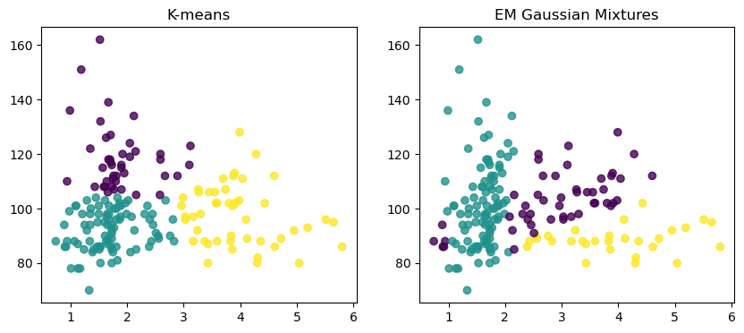

```python
X = df[['malic_acid', "magnesium"]].to_numpy()
"""
ptp is removed from the latest numpy so I manually used the latest in all the above and further program.
"""
## X_norm = (X - X.min(0)) / X.ptp(0) ## `ptp` was removed from the ndarray class in NumPy 2.0. Use np.ptp(arr, ...) instead.
X_norm = (X - X.min(axis=0)) / np.ptp(X, axis=0)
np.random.seed(RANDOM_SEED)

n_clusters = 3
kmeans_clustering = KMeans(n_clusters=n_clusters).fit_predict(X_norm)

model = MyGMM(K=n_clusters)
model.fit(X_norm)
gmm_clustering = model.predict(X_norm)

fig, axes = plt.subplots(nrows=1, ncols=2, figsize=(10,4))
axes[0].scatter(X[:, 0], X[:, 1], alpha=0.8, c=kmeans_clustering)
axes[0].set_title(f"K-means")

axes[1].scatter(X[:, 0], X[:, 1], alpha=0.8, c=gmm_clustering)
axes[1].set_title(f"EM Gaussian Mixtures")
```

**[Motivate]**  
A) Can you see the substantial difference between those two clusterings? Explain it.

(*if you don't see any difference try running the algorithm again*)

**YOUR ANSWER HERE**

In our plot, K‐Means is forming roughly one cluster on the left, one on the top/middle, and one on the right—straight boundary splits. GMM forms clusters with potentially different shapes or orientations—some points that K‐Means holds together may end up in another Gaussian component if it fits that region better (given mean + covariance).

Hence, yes, we see a substantial difference: GMM can better adapt to varying cluster shapes, often producing different group assignments than K‐Means’ single‐radius lumps. That can lead to noticeably different cluster allocations, even though both use 3 clusters and the same data.

**[Motivate]**  
B) What are the advantages and disadvantages of this approach?

**YOUR ANSWER HERE**

**Advantages:**

1. **Flexible Cluster Shapes:** Each Gaussian component has its own mean and covariance matrix, so clusters can be elliptical, tilted, or vary in spread whereas K‐Means, which assumes spherical clusters around a centroid.
2. **Soft Assignments:** GMM (EM) provides probabilistic membership: each point has a posterior probability of belonging to each cluster. This can be useful if points genuinely belong to multiple “mixed” groups or you want to measure confidence.
3. **Better Fit to Real Distributions:** Many real-world datasets approximate or contain subpopulations that are well-modeled by multivariate Gaussians. GMM can handle that scenario gracefully.

**Disadvantages:**

1. **Initialization Sensitivity:** The EM algorithm can converge to local maxima. Different random initial means (and covariances) may produce substantially different final solutions. A poor initialization can lead to a suboptimal solution.
2. **Computational Complexity:** GMM with full covariance matrices requires inverting a d×d matrix for each cluster at each E-step, so it can be more expensive than K‐Means, especially if the dimensionality or number of clusters is large.
3. **Interpretability:** Soft clusters can be less straightforward to interpret if we prefer a hard assignment. Also, covariance shapes might be more complex to visualize in high dimensions.

Therefore, In short, the Gaussian Mixture Model approach with EM is powerful for complex, elliptical clusters and soft memberships, but it requires careful initialization, can be computationally heavier, and may overfit if not regulated.

# Part 4 Outlier detection

In this exercise we will work with outlier detection techniques and analyze their performance on the small dataset. Before starting the exercise, run the code below.

```python
X = df[['malic_acid', "magnesium"]].to_numpy()
#X_norm = (X - X.min(0)) / X.ptp(0)
X_norm = (X - X.min(axis=0)) / np.ptp(X, axis=0)
```

## Task 4.1 (DBoutliers)

We will now compare two outlier detection techniques.

### Task 4.1.1 (2 points)

**[Implement]** a simple distance-based outlier detector. This is the distance-based outlier detection from the lectures, where a point is considered an outlier if at most a fraction $pi$ of the other points have a distance less of than $eps$ to it.

```python
def DBOutliers(X, eps, pi):
    outliers = None
    ### YOUR CODE STARTS HERE
    X = np.asarray(X)
    n = X.shape[0]

    outliers = []

    min_neighbors = pi * (n - 1)  # or pi*n, depending on your definition

    for i in range(n):
        # compute distance from x_i to all points
        dist = np.linalg.norm(X - X[i], axis=1)

        # how many are within eps? Exclude the point itself => subtract 1
        count_in_eps = np.sum(dist < eps) - 1

        # if count_in_eps < min_neighbors => outlier
        if count_in_eps < min_neighbors:
            outliers.append(i)

    ### YOUR ENDS CODE HERE
    return outliers

eps, pi = 0.18, 0.2
outlier = (DBOutliers(X_norm,eps,pi))

print(len(outlier))
```

```
70
```

### Task 4.1.2 (4 points)

A) **[Implement]** DBOutliers requires tuning the parameters eps, pi. Run the code from Task 4.1.1 with different choices of eps, pi

**Note** that the data is normalized. Choose two ranges with **at least** 4 values each.

```
For eps=0.05, pi=0.05, #Outliers=130, Outlier indices=[0, 2, 3, 4, 7, 9, 10, 16, 17, 18, 19, 20, 21, 25, 28, 33, 39, 40, 41, 43, 45, 46, 48, 53, 54, 55, 56, 58, 59, 60, 61, 62, 63, 64, 65, 66, 67, 68, 69, 70, 73, 74, 76, 77, 78, 79, 80, 81, 82, 83, 84, 85, 88, 89, 90, 92, 93, 95, 96, 97, 98, 99, 100…
For eps=0.05, pi=0.1, #Outliers=178, Outlier indices=[0, 1, 2, 3, 4, 5, 6, 7, 8, 9, 10, 11, 12, 13, 14, 15, 16, 17, 18, 19, 20, 21, 22, 23, 24, 25, 26, 27, 28, 29, 30, 31, 32, 33, 34, 35, 36, 37, 38, 39, 40, 41, 42, 43, 44, 45, 46, 47, 48, 49, 50, 51, 52, 53, 54, 55, 56, 57, 58, 59, 60, 61, 62, 63, …
For eps=0.05, pi=0.2, #Outliers=178, Outlier indices=[0, 1, 2, 3, 4, 5, 6, 7, 8, 9, 10, 11, 12, 13, 14, 15, 16, 17, 18, 19, 20, 21, 22, 23, 24, 25, 26, 27, 28, 29, 30, 31, 32, 33, 34, 35, 36, 37, 38, 39, 40, 41, 42, 43, 44, 45, 46, 47, 48, 49, 50, 51, 52, 53, 54, 55, 56, 57, 58, 59, 60, 61, 62, 63, …
For eps=0.05, pi=0.3, #Outliers=178, Outlier indices=[0, 1, 2, 3, 4, 5, 6, 7, 8, 9, 10, 11, 12, 13, 14, 15, 16, 17, 18, 19, 20, 21, 22, 23, 24, 25, 26, 27, 28, 29, 30, 31, 32, 33, 34, 35, 36, 37, 38, 39, 40, 41, 42, 43, 44, 45, 46, 47, 48, 49, 50, 51, 52, 53, 54, 55, 56, 57, 58, 59, 60, 61, 62, 63, …
For eps=0.05, pi=0.4, #Outliers=178, Outlier indices=[0, 1, 2, 3, 4, 5, 6, 7, 8, 9, 10, 11, 12, 13, 14, 15, 16, 17, 18, 19, 20, 21, 22, 23, 24, 25, 26, 27, 28, 29, 30, 31, 32, 33, 34, 35, 36, 37, 38, 39, 40, 41, 42, 43, 44, 45, 46, 47, 48, 49, 50, 51, 52, 53, 54, 55, 56, 57, 58, 59, 60, 61, 62, 63, …
For eps=0.1, pi=0.05, #Outliers=51, Outlier indices=[0, 4, 19, 20, 25, 33, 39, 41, 45, 66, 67, 68, 69, 73, 77, 78, 83, 89, 95, 96, 99, 113, 118, 119, 122, 123, 124, 129, 130, 136, 137, 138, 143, 144, 146, 147, 149, 150, 151, 155, 156, 160, 165, 166, 167, 169, 173, 174, 175, 176, 177]
For eps=0.1, pi=0.1, #Outliers=95, Outlier indices=[0, 2, 4, 7, 16, 19, 20, 21, 25, 33, 39, 41, 43, 45, 46, 59, 60, 66, 67, 68, 69, 73, 74, 76, 77, 78, 79, 80, 82, 83, 84, 85, 88, 89, 93, 95, 96, 99, 102, 105, 110, 111, 112, 113, 118, 119, 120, 121, 122, 123, 124, 125, 129, 130, 131, 133, 135, 136, …
For eps=0.1, pi=0.2, #Outliers=152, Outlier indices=[0, 2, 3, 4, 5, 6, 7, 9, 10, 15, 16, 17, 18, 19, 20, 21, 25, 28, 31, 32, 33, 34, 36, 39, 40, 41, 42, 43, 44, 45, 46, 48, 49, 52, 53, 54, 55, 56, 57, 58, 59, 60, 61, 62, 63, 64, 65, 66, 67, 68, 69, 71, 72, 73, 74, 75, 76, 77, 78, 79, 80, 81, 82, 83,…
For eps=0.1, pi=0.3, #Outliers=178, Outlier indices=[0, 1, 2, 3, 4, 5, 6, 7, 8, 9, 10, 11, 12, 13, 14, 15, 16, 17, 18, 19, 20, 21, 22, 23, 24, 25, 26, 27, 28, 29, 30, 31, 32, 33, 34, 35, 36, 37, 38, 39, 40, 41, 42, 43, 44, 45, 46, 47, 48, 49, 50, 51, 52, 53, 54, 55, 56, 57, 58, 59, 60, 61, 62, 63, 6…
For eps=0.1, pi=0.4, #Outliers=178, Outlier indices=[0, 1, 2, 3, 4, 5, 6, 7, 8, 9, 10, 11, 12, 13, 14, 15, 16, 17, 18, 19, 20, 21, 22, 23, 24, 25, 26, 27, 28, 29, 30, 31, 32, 33, 34, 35, 36, 37, 38, 39, 40, 41, 42, 43, 44, 45, 46, 47, 48, 49, 50, 51, 52, 53, 54, 55, 56, 57, 58, 59, 60, 61, 62, 63, 6…
For eps=0.2, pi=0.05, #Outliers=8, Outlier indices=[39, 69, 73, 78, 95, 123, 137, 173]
For eps=0.2, pi=0.1, #Outliers=21, Outlier indices=[33, 39, 69, 73, 78, 95, 96, 118, 123, 124, 129, 136, 137, 143, 146, 147, 150, 155, 169, 173, 175]
For eps=0.2, pi=0.2, #Outliers=57, Outlier indices=[0, 4, 19, 20, 21, 25, 33, 39, 41, 43, 45, 46, 66, 69, 73, 77, 78, 79, 83, 89, 93, 95, 96, 99, 110, 118, 119, 122, 123, 124, 129, 130, 133, 136, 137, 138, 143, 144, 146, 147, 149, 150, 155, 156, 160, 161, 162, 163, 165, 166, 167, 169, 173, 174, 175,…
For eps=0.2, pi=0.3, #Outliers=82, Outlier indices=[0, 4, 7, 16, 17, 19, 20, 21, 25, 33, 39, 40, 41, 43, 45, 46, 54, 55, 56, 66, 67, 68, 69, 73, 76, 77, 78, 79, 82, 83, 89, 93, 95, 96, 99, 110, 113, 118, 119, 121, 122, 123, 124, 129, 130, 131, 133, 136, 137, 138, 139, 140, 142, 143, 144, 145, 146, 1…
For eps=0.2, pi=0.4, #Outliers=112, Outlier indices=[0, 3, 4, 5, 7, 15, 16, 17, 18, 19, 20, 21, 25, 33, 36, 39, 40, 41, 43, 45, 46, 52, 53, 54, 55, 56, 58, 59, 63, 66, 67, 68, 69, 73, 76, 77, 78, 79, 80, 82, 83, 84, 85, 88, 89, 90, 92, 93, 95, 96, 97, 98, 99, 105, 106, 110, 111, 112, 113, 114, 118, …
For eps=0.4, pi=0.05, #Outliers=1, Outlier indices=[95]
For eps=0.4, pi=0.1, #Outliers=3, Outlier indices=[69, 95, 123]
For eps=0.4, pi=0.2, #Outliers=6, Outlier indices=[69, 95, 123, 137, 146, 173]
For eps=0.4, pi=0.3, #Outliers=16, Outlier indices=[39, 69, 73, 78, 95, 123, 129, 136, 137, 143, 146, 147, 155, 169, 173, 175]
For eps=0.4, pi=0.4, #Outliers=24, Outlier indices=[39, 45, 69, 73, 78, 83, 95, 96, 122, 123, 124, 129, 136, 137, 143, 146, 147, 155, 156, 165, 169, 173, 175, 177]
For eps=0.6, pi=0.05, #Outliers=0, Outlier indices=[]
For eps=0.6, pi=0.1, #Outliers=0, Outlier indices=[]
For eps=0.6, pi=0.2, #Outliers=0, Outlier indices=[]
For eps=0.6, pi=0.3, #Outliers=3, Outlier indices=[95, 123, 173]
For eps=0.6, pi=0.4, #Outliers=7, Outlier indices=[69, 95, 123, 137, 146, 155, 173]
```

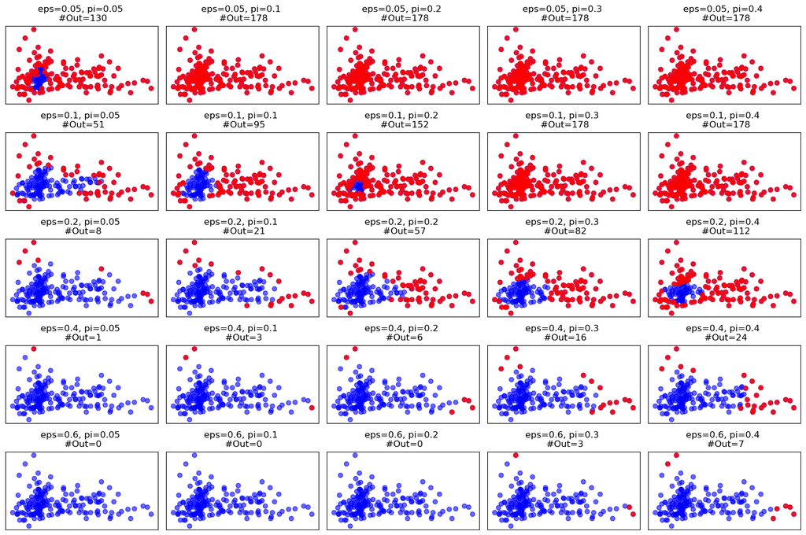

```python
### YOUR CODE HERE
eps_values = [0.05, 0.1, 0.2, 0.4, 0.6]   # at least 4 distinct values
pi_values  = [0.05, 0.1, 0.2, 0.3, 0.4]  # also at least 4 distinct values

results = []

for eps in eps_values:
    for pi in pi_values:
        outliers = DBOutliers(X_norm, eps, pi)
        n_outliers = len(outliers)

        results.append((eps, pi, n_outliers, outliers))

        print(f"For eps={eps}, pi={pi}, #Outliers={n_outliers}, Outlier indices={outliers}")



fig, axes = plt.subplots(nrows=len(eps_values), ncols=len(pi_values), figsize=(15, 10))

for r, eps in enumerate(eps_values):
    for c, pi in enumerate(pi_values):
        outliers = DBOutliers(X_norm, eps, pi)

        ax = axes[r][c]
        ax.scatter(X_norm[:,0], X_norm[:,1], alpha=0.6, color='blue')
        if len(outliers) > 0:
            ax.scatter(X_norm[outliers,0], X_norm[outliers,1], color='red', alpha=0.8, label='Outliers')
        ax.set_title(f"eps={eps}, pi={pi} \n #Out={len(outliers)}")
        ax.set_xticks([])
        ax.set_yticks([])

plt.tight_layout()
plt.show()

### YOUR CODE HERE
```

B) **[Motivate]**

**Present** the results and **discuss** how the results vary with respect to (1) eps and (2) pi.

**YOUR ANSWER HERE**

1. **Small $\epsilon$ = Stricter Neighborhood:**
- Only points extremely close together are considered neighbors.
- Most points fail to achieve the minimum required neighbor count, so we see more outliers.
- Outliers typically become all but the tight clusters.
2. **Large $\epsilon$ = Looser Neighborhood:**
- Points are considered neighbors even if they are moderately far apart.
- More points surpass the required neighbor threshold, so we see fewer outliers.
- Eventually, if $\epsilon$ is big enough, almost all points neighbor each other causes near zero outliers.
3. **Small $\pi$ = Low Fraction Threshold:**
- Fewer points get flagged = fewer outliers.
- Even if we have a moderate neighbor count, that might surpass a small fraction threshold.
4. **Large $\pi$ = High Fraction Threshold**
- A point must have many neighbors (a large fraction of the dataset) within $\epsilon$.
- More outliers or labeling all else outliers.

As we increase $\epsilon$, the number of outliers decreases. With a very small $\epsilon$, almost everyone is considered an outlier unless they are in a tight local cluster. Otherhand, as we increase $\pi$, the algorithm demands more neighbors for a point not to be an outlier, so the outlier count rises.

## Task 4.2 Isolation Forest (8 points)

In this section you will recreate implementation of the Isolation Forest from the original paper: https://ieeexplore.ieee.org/abstract/document/4781136.

**Note**: To access the PDF, you must be connected to the university's Wi-Fi or VPN.

A) **[Implement]** Fill missing parts in the code below.

```python
def c(n):
    """
    Defined by the equation (1) in the paper.\\
    Computes the expected path length for a given tree size based on the average depth of
    a randomly generated binary search tree.

    Parameters:
    -----------
    n (int): The number of data points in the node.

    Returns:
    -----------
    float: The expected path length.
    """
    if n <= 1:
        return 0
    ### YOUR CODE STARTS HERE

    # Compute the harmonic number H_n
    H = 0.0
    for i in range(1, n+1):
        H += 1.0 / i

    return 2.0 * (H - 1.0)

    ### YOUR CODE ENDS HERE



class IsolationTree:
    def __init__(self):
        self.left = None
        self.right = None
        self.split_feature = None
        self.split_value = None
        self.size = 0


    def fit(self, X, e, l):
        """
        Defined by the Algorithm 2 in the paper.\\
        Trains the tree on data X.\\
        It's already implemented for you. Do not modify it.

        Parameters:
        -----------
        X: array-like, shape (n_samples, n_features)
        e: current tree height
        l: height limit

        Returns:
        -----------
        IsolationTree: itself
        """
        self.size = len(X)

        if e >= l or self.size <= 1:
            return self

        # Choose a random feature and split value
        self.split_feature = np.random.randint(X.shape[1])
        min_val, max_val = X[:, self.split_feature].min(), X[:, self.split_feature].max()

        if min_val == max_val:
            return self

        self.split_value = np.random.uniform(min_val, max_val)

        left_mask = X[:, self.split_feature] < self.split_value
        X_left, X_right = X[left_mask], X[~left_mask]

        self.left = IsolationTree().fit(X_left, e + 1, l)
        self.right = IsolationTree().fit(X_right, e + 1, l)

        return self


    def is_external_node(self):
        """
        Checks whether the tree is an external node.\\
        For the definition of external node ctr+F 'external-node' in the paper.

        Returns:
        -----------
        Boolean: True is the tree is an external node, otherwise, False.
        """
        ### YOUR CODE STARTS HERE
        return (self.left is None) and (self.right is None)


        ### YOUR CODE ENDS HERE



    def path_length(self, x, e=0):
        """
        Defined by the Algorithm 3 in the paper.

        Parameters:
        -----------
        x: array-like, shape (n_features,)
        e: current tree height

        Returns:
        -----------
        int: path length of x
        """
        ### YOUR CODE STARTS HERE
        if self.is_external_node():
            return e + c(self.size)
        # Otherwise, follow the split
        if x[self.split_feature] < self.split_value:
            return self.left.path_length(x, e + 1)
        else:
            return self.right.path_length(x, e + 1)

        ### YOUR CODE ENDS HERE


class IsolationForest:
    def __init__(self, n_trees, subsample_size):
        self.n_trees = n_trees
        self.subsample_size = subsample_size
        self.height_limit = np.ceil(np.log2(self.subsample_size))
        self.trees = []


    def fit(self, X):
        """
        Trains the forest on data X.

        Parameters:
        -----------
        X: array-like, shape (n_samples, n_features)
        """
        self.trees = []
        for _ in range(self.n_trees):
            sample = X[np.random.choice(X.shape[0], self.subsample_size, replace=False)]
            tree = IsolationTree().fit(sample, 0, self.height_limit)
            self.trees.append(tree)


    def anomaly_score(self, x):
        """
        Defined by equation (2) in the paper.\\
        Computes the anomaly score of instance x.

        Note:
        -----------
        Keep in mind that variable 'n' in the equation in the paper does not represent the size of X but rather the size of a tree i.e. sub-sampling size.

        Parameters:
        -----------
        x: array-like, shape (n_features,)

        Returns:
        -----------
        float: the anomaly score of instance x
        """
        ### YOUR CODE STARTS HERE
        total_pl = 0.0
        for tree in self.trees:
            total_pl += tree.path_length(x)
        avg_pl = total_pl / len(self.trees)
        return 2.0 ** ( - avg_pl / c(self.subsample_size) )


        ### YOUR CODE ENDS HERE


    def identify_outliers(self, X, threshold=0.5):
        """
        Identifies outliers in the X based on an anomaly score.

        Parameters:
        -----------
        X : array-like, shape (n_samples, n_features)
        threshold: the cutoff value for determining whether a sample is an outlier.

        Returns:
        -----------
        outliers : array-like, shape (n_samples,)\\
        A boolean array where each element corresponds to a sample in X.\\
        True indicates that the anomaly score of the sample is greater than the threshold.
        """
        ### YOUR CODE STARTS HERE
        outliers = []
        for x in X:
            score = self.anomaly_score(x)
            outliers.append(score > threshold)
        return np.array(outliers, dtype=bool)
        ### YOUR CODE ENDS HERE
```

B). **[Implement]** Create an Isolation Forest with $n\_trees = 100$, $subsample\_size = 50$ and train it on $X$. Then, use the Isolation Forest to find outliers in $X$ and plot the result. You might need to fine-tune parameter $threshold$ so that the result is meaningful.

```
Number of outliers: 13
```

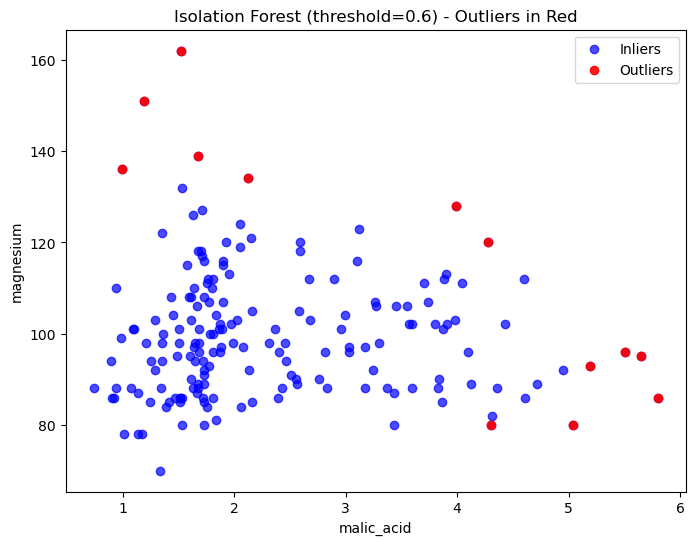

```python
X = df[['malic_acid', "magnesium"]].to_numpy()
X_norm = (X - X.min(axis=0)) / np.ptp(X, axis=0)
#X_norm = (X - X.min(0)) / X.ptp(0)

### YOUR CODE STARTS HERE
model = IsolationForest(n_trees=100, subsample_size=50)
model.fit(X_norm)

# 2) Pick a threshold for anomaly score
threshold = 0.6 # Feel free to tweak this

# 3) Identify outliers
outliers = model.identify_outliers(X_norm, threshold=threshold)
print(f"Number of outliers: {outliers.sum()}")

# 4) Plot
fig, ax = plt.subplots(figsize=(8,6))

ax.scatter(X[:, 0], X[:, 1], c="blue", alpha=0.7, label="Inliers")

# Outliers in red
ax.scatter(X[outliers, 0], X[outliers, 1], c="red", alpha=0.9, label="Outliers")

ax.set_xlabel("malic_acid")
ax.set_ylabel("magnesium")
ax.set_title(f"Isolation Forest (threshold={threshold}) - Outliers in Red")
ax.legend()
plt.show()



### YOUR CODE ENDS HERE
```

C) **[Motivate]** Present the results and discuss what you found and what is the impact of $threshold$.

**YOUR ANSWER HERE**

Here, we set the threshold value to `0.6`

The threshold directly controls the sensitivity of outlier detection:

Lower threshold (e.g., 0.5): Increases outlier count by flagging more borderline anomalies (higher false positives). If we slightly decrease the value more it may produce more outliers or consider the all points to outliers.

Higher threshold (e.g., 0.7): Reduces outlier count by only capturing extreme deviations (higher false negatives). Also, If we slightly increase the value more it will not or detect any outliers.

At 0.6, the model balances specificity and sensitivity, targeting significant deviations in `malic_acid` and `magnesium` levels. This threshold choice implies a focus on minimizing false alarms while still capturing meaningful outliers.